# Monumentome supplementary figures

Main-text figures are in `paper_figures.Rmd`.

Supplementary Figure 1 shows the sequencing controls as sequenced. Two samples that had been typed as positive standards did not match the ZymoBIOMICS mix, and those rows were removed from the metadata. They are not in this file. The noise found in the two matched positive standards is subtracted from every remaining sample by `decontaminate_metaphlan.R`, and every figure from Supplementary Figure 2 on, like every main-text figure, uses that transformed table. Positive and negative sequencing controls are excluded from every analysis figure; the three Tel Megiddo swabs typed `control` are touched-rock swabs and stay in.

Material colors stay the same wherever a figure encodes material: rock/stone `#009E73`, granite `#CC79A7`, metal `#8C510A`, marble `#E69F00`, others `#0072B2`. A focal monument-material group keeps the color of its material. This file does not use those fills for library size, because file size is not a material. Dropped samples stay red, as in the sequencing-size scatter from the analysis notebook.

Each new chunk is preceded by a short explanation of what that panel shows and what was changed from the analysis notebook.

```r
suppressPackageStartupMessages({
  library(readr)
  library(dplyr)
  library(tidyr)
  library(stringr)
  library(ggplot2)
  library(patchwork)
  library(cowplot)
  library(vegan)
  library(readxl)
})

ROOT <- normalizePath(".", winslash = "/")
METADATA_FILE <- file.path(ROOT, "input", "Monumentome_metadata.csv")
# The raw MetaPhlAn table is used only for Supplementary Figure 1 (the controls as
# sequenced). Every other figure uses the positive-control-noise-subtracted table
# written by decontaminate_metaphlan.R.
METAPHLAN_RAW_FILE <- file.path(ROOT, "input", "metaphlan_merged_all_taxa.tsv")
METAPHLAN_FILE <- file.path(ROOT, "input", "metaphlan_merged_all_taxa_decontaminated.tsv")
NOISE_FILE <- file.path(ROOT, "input", "positive_control_noise_species.tsv")
# Sequencing controls are never analysed as monument samples.
SEQUENCING_CONTROL_TYPES <- c("positive_control", "negative_control")
OUTPUT_DIR <- file.path(ROOT, "paper_output")
dir.create(OUTPUT_DIR, showWarnings = FALSE, recursive = TRUE)

MIN_DETECTED_SPECIES <- 2L
RANDOM_SEED <- 123L
ELLIPSE_LEVEL <- 0.75
N_PERMUTATIONS <- 999L
RICHNESS_PERMUTATIONS <- 100L
CORE_THRESHOLD <- 0.75
TMD_FILE <- file.path(ROOT, "input", "TMD_data.csv")
MATERIAL_COLORS <- c(
  "rock/stone" = "#009E73",
  "granite" = "#CC79A7",
  "metal" = "#8C510A",
  "marble" = "#E69F00",
  "others" = "#0072B2"
)
FOCAL_GROUP_LEVELS <- c(
  "Brazil \u2014 granite",
  "Israel \u2014 others",
  "Israel \u2014 rock/stone",
  "United States \u2014 marble",
  "United States \u2014 metal"
)
FOCAL_GROUP_COLORS <- setNames(
  unname(MATERIAL_COLORS[c("granite", "others", "rock/stone", "marble", "metal")]),
  FOCAL_GROUP_LEVELS
)
# Check panels are wide enough for "United States" on one line. In the A4 print pages the
# bars are narrower than that at 7 pt, so "United States" is split over two lines.
FOCAL_AXIS_LABELS_CHECK <- setNames(
  c(
    "Brazil\ngranite",
    "Israel\nothers",
    "Israel\nrock/stone",
    "United States\nmarble",
    "United States\nmetal"
  ),
  FOCAL_GROUP_LEVELS
)
FOCAL_AXIS_LABELS_PRINT <- setNames(
  c(
    "Brazil\ngranite",
    "Israel\nothers",
    "Israel\nrock/stone",
    "United\nStates\nmarble",
    "United\nStates\nmetal"
  ),
  FOCAL_GROUP_LEVELS
)
focal_axis_labels <- function() if (is_print()) FOCAL_AXIS_LABELS_PRINT else FOCAL_AXIS_LABELS_CHECK
FOCAL_LEGEND_LABELS <- setNames(
  c(
    "Brazil - granite",
    "Israel - others",
    "Israel - rock/stone",
    "United States - marble",
    "United States - metal"
  ),
  FOCAL_GROUP_LEVELS
)
DROPPED_SAMPLE_COLOR <- "#D73027"
RETAINED_SAMPLE_COLOR <- "grey20"
# Paul Tol safe qualitative colors, ordered so the first entries stay dark on white.
TOL_SAFE <- c(
  "#332288", "#117733", "#CC6677", "#88CCEE", "#AA4499",
  "#661100", "#44AA99", "#882255", "#6699CC", "#999933", "#000000"
)
LIBRARY_COLORS <- c(
  "Original bases" = "#4D4D4D",
  "Clean bases" = "#56B4E9"
)

clean_sample_id <- function(x) {
  x <- basename(as.character(x))
  x <- str_remove(x, "\\.(fastq|fq)(\\.gz)?$")
  x <- str_remove(x, "_R[12](_001)?$")
  x <- str_remove(x, "_S[0-9]+.*$")
  x
}

# Figure theme, Jaccard NMDS, Mann-Whitney brackets, and PNG/PDF savers.
FIG_FONT <- "Helvetica"
PRINT_WIDTH_IN <- 180 / 25.4     # 7.09 in, the maximum width allowed
PRINT_MAX_HEIGHT_IN <- 10.6      # A4 is 11.69 in; leaves room for a page margin
PRINT_DPI <- 600
CHECK_DPI <- 300

set_figure_mode <- function(mode = c("check", "print")) {
  mode <- match.arg(mode)
  sizes <- switch(
    mode,
    check = list(
      FIG_BASE_SIZE = 15, FIG_TITLE_SIZE = 17, FIG_AXIS_TITLE_SIZE = 16,
      FIG_LEGEND_TEXT_SIZE = 13, FIG_LEGEND_TITLE_SIZE = 14, FIG_TAG_SIZE = 24,
      FIG_SMALL_TEXT_SIZE = 12, FIG_GEOM = 1
    ),
    print = list(
      FIG_BASE_SIZE = 7, FIG_TITLE_SIZE = 7, FIG_AXIS_TITLE_SIZE = 7,
      FIG_LEGEND_TEXT_SIZE = 6, FIG_LEGEND_TITLE_SIZE = 7, FIG_TAG_SIZE = 8,
      FIG_SMALL_TEXT_SIZE = 6, FIG_GEOM = 0.45
    )
  )
  assign("FIG_MODE", mode, envir = globalenv())
  for (nm in names(sizes)) assign(nm, sizes[[nm]], envir = globalenv())
  invisible(mode)
}
set_figure_mode("check")

is_print <- function() identical(FIG_MODE, "print")
pt_to_mm <- function(pt) pt / ggplot2::.pt
gs <- function(x) x * FIG_GEOM          # point sizes and line widths
# In print mode every size that is written in inches for the check figures is scaled down
# by the same ratio as the text (7 pt / 15 pt).
fs <- function(x) x * FIG_BASE_SIZE / 15
# Choose a value by mode.
by_mode <- function(check, print) if (is_print()) print else check

# Axis titles sit a few points from the tick labels, never far away.
paper_theme <- function(base_size = FIG_BASE_SIZE, angle_x = TRUE) {
  m <- base_size / 15   # margins scale with the text
  theme_classic(base_size = base_size, base_family = FIG_FONT) +
    theme(
      plot.title = element_text(face = "bold", size = FIG_TITLE_SIZE, margin = margin(t = 10 * m, b = 6 * m)),
      plot.title.position = "plot",
      plot.subtitle = element_text(size = base_size, margin = margin(b = 4 * m)),
      plot.tag = element_text(face = "bold", size = FIG_TAG_SIZE),
      axis.title.x = element_text(size = FIG_AXIS_TITLE_SIZE, margin = margin(t = 5 * m)),
      axis.title.y = element_text(size = FIG_AXIS_TITLE_SIZE, margin = margin(r = 5 * m)),
      axis.text = element_text(size = base_size, colour = "black"),
      axis.text.x = if (angle_x) {
        element_text(angle = 40, hjust = 1, vjust = 1, colour = "black")
      } else {
        element_text(angle = 0, hjust = 0.5, vjust = 1, lineheight = 0.95, colour = "black")
      },
      axis.ticks.length = unit(4 * m, "pt"),
      axis.line = element_line(linewidth = gs(0.5)),
      axis.ticks = element_line(linewidth = gs(0.5)),
      legend.title = element_text(face = "bold", size = FIG_LEGEND_TITLE_SIZE),
      legend.text = element_text(size = FIG_LEGEND_TEXT_SIZE),
      legend.key.size = unit(0.55 * m, "cm"),
      strip.text = element_text(face = "bold", size = base_size),
      plot.margin = margin(8 * m, 14 * m, 8 * m, 8 * m)
    )
}
```

```r
paper_theme_continuous <- function(base_size = FIG_BASE_SIZE) {
  paper_theme(base_size, angle_x = FALSE)
}

# Theme for panels with many categorical tick labels that stay upright.
paper_theme_upright <- function(base_size = FIG_BASE_SIZE) {
  paper_theme(base_size, angle_x = FALSE)
}

# Blank theme for Venn diagrams, with the same text sizes.
venn_theme <- function() {
  theme_void(base_size = FIG_BASE_SIZE, base_family = FIG_FONT) +
    theme(
      plot.title = element_text(face = "bold", hjust = 0.5, size = FIG_TITLE_SIZE),
      plot.tag = element_text(face = "bold", size = FIG_TAG_SIZE),
      legend.title = element_text(face = "bold", size = FIG_LEGEND_TITLE_SIZE),
      legend.text = element_text(size = FIG_LEGEND_TEXT_SIZE),
      legend.key.height = unit(by_mode(0.8, 0.35), "cm"),
      legend.key.width = unit(by_mode(0.5, 0.25), "cm"),
      plot.margin = margin(by_mode(8, 3), by_mode(14, 5), by_mode(8, 3), by_mode(8, 3))
    )
}

# Axis, legend, and title text. Accented names are kept in the metadata and
# reduced here, because the figure device prints a missing glyph as <U+XXXX>.
plot_label <- function(x) {
  y <- as.character(x)
  ok <- !is.na(y)
  y[ok] <- stringi::stri_trans_general(y[ok], "Latin-ASCII")
  y[ok] <- str_replace_all(y[ok], "\u00b2", "2")
  y[ok] <- str_replace_all(y[ok], "\u00b3", "3")
  bad <- y[ok & grepl("[^\x01-\x7F]", y)]
  if (length(bad) > 0) {
    stop("A plot label still contains a character the figure device cannot draw: ", paste(unique(bad), collapse = " | "))
  }
  y
}

figure_text <- function(x, depth = 0L) {
  if (is.null(x) || depth > 40L) return(character())
  if (inherits(x, "ggplot")) x <- ggplotGrob(x)
  out <- character()
  lab <- x$label
  if (is.expression(lab) || is.language(lab) || is.symbol(lab)) lab <- as.character(lab)
  if (is.character(lab)) out <- c(out, lab)
  if (!is.null(x$children)) out <- c(out, unlist(lapply(x$children, figure_text, depth + 1L), use.names = FALSE))
  if (!is.null(x$grobs)) out <- c(out, unlist(lapply(x$grobs, figure_text, depth + 1L), use.names = FALSE))
  out
}

save_figure <- function(filename, plot, ...) {
  labels <- figure_text(plot)
  bad <- labels[grepl("[^\x01-\x7F]|<U\\+", labels)]
  if (length(bad) > 0) {
    stop("Figure text is not plain ASCII:\n", paste(unique(bad), collapse = "\n"))
  }
  ggsave(filename, plot, ...)
}

# Check mode: save one panel as a PNG inside the figure's own folder. In print mode this
# does nothing, so the same chunk can be run in both modes. Returns the path or NULL.
save_panel <- function(plot, figure_dir, file_name, width, height, dpi = CHECK_DPI) {
  if (is_print()) return(invisible(NULL))
  dir.create(figure_dir, showWarnings = FALSE, recursive = TRUE)
  path <- file.path(figure_dir, paste0(file_name, ".png"))
  save_figure(path, plot, width = width, height = height, units = "in", dpi = dpi, bg = "white")
  invisible(path)
}

# Each panel is wrapped as an independent block, so panels are not aligned to each other
# and no axis title is pushed away from its axis by a neighbour's tick labels.
blk <- function(p) patchwork::wrap_elements(full = p)

# vegan permutation tests report p = (d+1)/(N+1). With N = 999 the smallest value is
# 0.001, which means none of the permutations was as extreme as the observed statistic.
perm_p_text <- function(p, nperm = 999L) {
  p <- as.numeric(p)[[1]]
  floor_p <- 1 / (as.numeric(nperm)[[1]] + 1)
  if (is.finite(p) && p <= floor_p + 1e-12) {
    sprintf("p < %.3g", floor_p)
  } else {
    sprintf("p = %.3g", p)
  }
}

# Jaccard presence-absence distances, PERMANOVA, and 2-D NMDS. Taxa found in
# only one sample are dropped: they inflate Jaccard toward 1 and make 2-D NMDS
# degenerate. Samples that then have no remaining taxa are dropped from the
# distance matrix. NMDS has no percent-explained axes; stress is reported instead.
jaccard_beta <- function(mat, group, nperm = 999L, seed = 123L, trymax = 200L, min_occupancy = 2L) {
  if (is.null(rownames(mat))) rownames(mat) <- as.character(seq_len(nrow(mat)))
  pa <- (mat > 0) * 1
  storage.mode(pa) <- "numeric"
  rownames(pa) <- rownames(mat)
  if (min_occupancy > 1L && ncol(pa) > 0) {
    pa <- pa[, colSums(pa) >= min_occupancy, drop = FALSE]
  }
  keep <- rowSums(pa) > 0
  dropped_samples <- rownames(pa)[!keep]
  pa <- pa[keep, , drop = FALSE]
  group <- group[keep]
  d <- vegan::vegdist(pa, method = "jaccard", binary = TRUE)
  grp <- data.frame(focal_group = group)
  set.seed(seed)
  permanova <- vegan::adonis2(d ~ focal_group, data = grp, permutations = nperm)
  set.seed(seed)
  nmds <- vegan::metaMDS(d, k = 2, trymax = trymax, trace = FALSE)
  scores <- as.data.frame(vegan::scores(nmds, display = "sites"))
  names(scores) <- c("NMDS1", "NMDS2")
  rownames(scores) <- rownames(pa)
  list(
    dist = d, permanova = permanova, nmds = nmds, scores = scores, stress = nmds$stress,
    dropped_samples = dropped_samples, n_samples = nrow(pa), n_taxa = ncol(pa)
  )
}

# Pairwise Mann-Whitney (Wilcoxon) tests with BH adjustment.
pairwise_mannwhitney <- function(x, g, p_adjust = "BH") {
  g <- droplevels(factor(g))
  lv <- levels(g)
  if (length(lv) < 2) {
    return(data.frame(group1 = character(), group2 = character(), p_raw = double(), p_adj = double(), stringsAsFactors = FALSE))
  }
  group1 <- character()
  group2 <- character()
  p_raw <- double()
  for (i in seq_len(length(lv) - 1L)) {
    for (j in (i + 1L):length(lv)) {
      xi <- x[g == lv[i] & is.finite(x)]
      xj <- x[g == lv[j] & is.finite(x)]
      p <- if (length(xi) < 2L || length(xj) < 2L) {
        NA_real_
      } else {
        stats::wilcox.test(xi, xj, exact = FALSE)$p.value
      }
      group1 <- c(group1, lv[i])
      group2 <- c(group2, lv[j])
      p_raw <- c(p_raw, p)
    }
  }
  data.frame(group1 = group1, group2 = group2, p_raw = p_raw, p_adj = stats::p.adjust(p_raw, method = p_adjust), stringsAsFactors = FALSE)
}

mw_p_text <- function(p) {
  p <- as.numeric(p)[[1]]
  if (!is.finite(p)) return("")
  if (p < 0.001) "p < 0.001" else sprintf("p = %.3g", p)
}
```

```r
# Square brackets for BH-significant pairwise Mann-Whitney tests.
mw_bracket_data <- function(y, group, pw) {
  sig <- pw[is.finite(pw$p_adj) & pw$p_adj < 0.05, , drop = FALSE]
  if (!nrow(sig)) return(sig)
  lv <- levels(droplevels(factor(group)))
  sig$i1 <- match(sig$group1, lv)
  sig$i2 <- match(sig$group2, lv)
  sig <- sig[order(sig$i2 - sig$i1, sig$i1), , drop = FALSE]
  ymax <- max(y[is.finite(y)], na.rm = TRUE)
  ymin <- min(y[is.finite(y)], na.rm = TRUE)
  rng <- ymax - ymin
  if (!is.finite(rng) || rng <= 0) rng <- max(abs(ymax), 1)
  sig$label <- vapply(sig$p_adj, mw_p_text, character(1))
  sig$y.position <- ymax + rng * 0.12 * seq_len(nrow(sig))
  sig
}

mw_kw_subtitle <- function(kw_p, pw) {
  sprintf("Kruskal-Wallis p = %.3g", kw_p)
}

# Print mode: save one A4-portrait page as PDF (vector) and PNG (600 dpi). In check mode
# this does nothing. The page must be at most 180 mm wide and must fit A4 portrait.
save_page <- function(plot, figure_dir, name, height, width = PRINT_WIDTH_IN) {
  if (!is_print()) return(invisible(NULL))
  if (width > PRINT_WIDTH_IN + 1e-6) stop(name, ": wider than 180 mm (", round(width * 25.4), " mm).")
  if (height > PRINT_MAX_HEIGHT_IN + 1e-6) stop(name, ": taller than the A4 page allows (", round(height, 2), " in).")
  dir.create(figure_dir, showWarnings = FALSE, recursive = TRUE)
  pdf_path <- file.path(figure_dir, paste0(name, ".pdf"))
  png_path <- file.path(figure_dir, paste0(name, ".png"))
  save_figure(pdf_path, plot, width = width, height = height, units = "in", device = grDevices::pdf, family = FIG_FONT)
  save_figure(png_path, plot, width = width, height = height, units = "in", dpi = PRINT_DPI, bg = "white")
  invisible(png_path)
}

# Named genera from sheet 1 of the validated literature table. Cutibacterium is marked
# "NOT recommended" and is left out; the Bryobacter aside on the Blastocatella row is left out.
literature_genera_from_sheet <- function(path) {
  sheet <- readr::read_csv(path, skip = 1, show_col_types = FALSE)
  status <- sheet[["Validation status"]]
  status[is.na(status)] <- ""
  genus_cells <- sheet$Genus[!stringr::str_detect(status, stringr::regex("NOT recommended", ignore_case = TRUE))]
  parsed <- lapply(genus_cells, function(cell) {
    if (is.na(cell)) return(character())
    cell <- stringr::str_replace_all(cell, "[^A-Za-z0-9 ;/._-]", " ")
    cell <- stringr::str_replace(cell, stringr::regex("also deterioration-associated Bryobacter.*$", ignore_case = TRUE), "")
    cell <- stringr::str_replace_all(cell, stringr::regex("-type AOA", ignore_case = TRUE), "")
    if (stringr::str_detect(cell, stringr::regex("unresolved|copper-resistant", ignore_case = TRUE))) return(character())
    parts <- stringr::str_trim(unlist(stringr::str_split(cell, "[;/]")))
    parts <- parts[stringr::str_detect(parts, "^[A-Z][A-Za-z0-9_.]*$|^Ca\\.")]
    unlist(lapply(parts, function(genus_name) {
      genus_name <- stringr::str_replace(genus_name, "^Ca\\.\\s*", "Candidatus_")
      genus_name <- stringr::str_replace_all(genus_name, " ", "_")
      if (genus_name == "Candidatus_Nitrocosmicus") {
        return(c("Candidatus_Nitrosocosmicus", "Nitrosocosmicus"))
      }
      if (genus_name == "Candidatus_Nitrosotenuis") return("Nitrosotenuis")
      genus_name
    }))
  })
  unique(unlist(parsed))
}

terminal_rank <- function(clade_name) {
  str_extract(str_extract(clade_name, "[^|]+$"), "^[kpcofgst]__")
}

normalize_material <- function(x) {
  x <- str_to_lower(str_squish(as.character(x)))
  case_when(
    is.na(x) | x == "" ~ "Unknown",
    x %in% c("rock", "stone", "rock/stone") ~ "rock/stone",
    x == "granite" ~ "granite",
    x == "marble" ~ "marble",
    x %in% c("metal", "bronze", "steel", "gold") ~ "metal",
    TRUE ~ "others"
  )
}
```

All analysis figures use a transformed MetaPhlAn table. `decontaminate_metaphlan.R` builds the noise list from the two positive standards whose profiles matched the ZymoBIOMICS mix: `BC-0247288828` (Soldier’s National Monument) and `BC-0302366907` (Orpheus). Every species those two standards contain that is not one of the ten D6300 organisms gets a ceiling equal to its higher abundance in the two. That ceiling is subtracted from the species in every remaining sample where it is present (floored at zero), the removal is carried up the lineage and into the strain bins, and each sample is renormalised so its top-level rows sum to 100 again. `BC-0247292781` and `BC-0302370816` did not match the mix, so those rows were removed from the metadata and from the transformed table. The script is run here so the table on disk always matches the raw table and the metadata. The noise list is shown under Supplementary Figure 1.

Phylum, genus, and species are counted separately from that transformed table. The rank is the last token of `clade_name` (`p__`, `g__`, or `s__`). A `t__` row is a genome bin under a species and is not added to the species count. A taxon is detected when its reported abundance is above zero. The table below is that count, before any focal-group filter.

```r
metadata <- read_csv(METADATA_FILE, show_col_types = FALSE, name_repair = "unique") %>%
  mutate(
    sample_name_clean = clean_sample_id(sample_name),
    monument_name = plot_label(str_squish(str_replace_all(as.character(monument), "_", " ")))
  )

QC_POSITIVE_CONTROLS <- c(
  "BC-0247288828",
  "BC-0302366907"
)
MISLABELED_SAMPLES <- c(
  "BC-0247292781",
  "BC-0302370816"
)

ZYMO_D6300_SPECIES <- c(
  "Pseudomonas_aeruginosa",
  "Escherichia_coli",
  "Salmonella_enterica",
  "Limosilactobacillus_fermentum",  # Zymo sheet: Lactobacillus fermentum
  "Enterococcus_faecalis",
  "Staphylococcus_aureus",
  "Listeria_monocytogenes",
  "Bacillus_spizizenii",            # Zymo sheet: Bacillus subtilis
  "Saccharomyces_cerevisiae",
  "Cryptococcus_neoformans"
)

decontaminate_metaphlan <- function(root = ".",
                                    metaphlan_file = file.path(root, "input", "metaphlan_merged_all_taxa.tsv"),
                                    metadata_file = file.path(root, "input", "Monumentome_metadata.csv"),
                                    noise_out = file.path(root, "input", "positive_control_noise_species.tsv"),
                                    table_out = file.path(root, "input", "metaphlan_merged_all_taxa_decontaminated.tsv"),
                                    positive_control_type = "positive_control",
                                    positive_control_ids = QC_POSITIVE_CONTROLS,
                                    zymo_species = ZYMO_D6300_SPECIES,
                                    quiet = FALSE) {
  strip_s_suffix <- function(x) str_remove(as.character(x), "_S[0-9]+.*$")

  header_lines <- readLines(metaphlan_file, n = 5)
  header_lines <- header_lines[str_starts(header_lines, "#")]

  mp <- read_tsv(metaphlan_file, comment = "#", show_col_types = FALSE, name_repair = "minimal")
  if ("#clade_name" %in% names(mp)) names(mp)[names(mp) == "#clade_name"] <- "clade_name"
  sample_cols <- setdiff(names(mp), c("clade_name", "NCBI_tax_id"))
  sample_ids <- strip_s_suffix(sample_cols)
  # Mislabeled positive controls are not part of the analysis table.
  drop_cols <- sample_cols[sample_ids %in% MISLABELED_SAMPLES]
  if (length(drop_cols) != length(MISLABELED_SAMPLES)) {
    stop("Mislabeled samples missing from the MetaPhlAn table: ",
         paste(setdiff(MISLABELED_SAMPLES, sample_ids), collapse = ", "))
  }
  sample_cols <- setdiff(sample_cols, drop_cols)
  sample_ids <- strip_s_suffix(sample_cols)

  metadata <- read_csv(metadata_file, show_col_types = FALSE, name_repair = "unique")
  metadata_ids <- unique(strip_s_suffix(metadata$sample_name))
  # Sample columns that are not in the metadata are not paper samples.
  sample_cols <- sample_cols[sample_ids %in% metadata_ids]
  sample_ids <- strip_s_suffix(sample_cols)
  typed_positive <- metadata %>%
    filter(sample_type == positive_control_type) %>%
    pull(sample_name) %>%
    strip_s_suffix()
  positive_ids <- strip_s_suffix(positive_control_ids)
  missing_ids <- setdiff(positive_ids, typed_positive)
  if (length(missing_ids) > 0) {
    stop("These QC positive controls are not typed ", positive_control_type, " in the metadata: ",
         paste(missing_ids, collapse = ", "))
  }
  positive_cols <- sample_cols[sample_ids %in% positive_ids]
  if (length(positive_cols) != length(positive_ids)) {
    stop("These QC positive controls have no MetaPhlAn column: ",
         paste(setdiff(positive_ids, sample_ids), collapse = ", "))
  }

  mat <- as.matrix(mp[, sample_cols])
  mode(mat) <- "numeric"
  mat[is.na(mat)] <- 0
  rownames(mat) <- mp$clade_name

  is_species_row <- str_detect(mp$clade_name, "\\|s__[^|]+$")
  species_name <- if_else(is_species_row, str_remove(str_extract(mp$clade_name, "[^|]+$"), "^s__"), NA_character_)

  # Noise list: species seen in a positive control that are not in the standard.
  pos_mat <- mat[is_species_row, positive_cols, drop = FALSE]
  rownames(pos_mat) <- species_name[is_species_row]
  seen <- rowSums(pos_mat > 0) > 0
  noise <- tibble(
    species = rownames(pos_mat)[seen],
    ceiling_abundance = apply(pos_mat[seen, , drop = FALSE], 1, max),
    n_positive_controls = rowSums(pos_mat[seen, , drop = FALSE] > 0),
    positive_controls = apply(pos_mat[seen, , drop = FALSE], 1, function(v) paste(strip_s_suffix(positive_cols)[v > 0], collapse = ";"))
  ) %>%
    filter(!species %in% zymo_species) %>%
    arrange(desc(ceiling_abundance))

  # Subtract each noise species, propagate, then renormalise.
  removed_total <- setNames(numeric(length(sample_cols)), sample_cols)
  samples_touched <- setNames(integer(nrow(noise)), noise$species)
  for (i in seq_len(nrow(noise))) {
    sp <- noise$species[i]
    row_i <- which(is_species_row & species_name == sp)
    if (length(row_i) != 1) stop("Species row not unique: ", sp)
    lineage <- mp$clade_name[row_i]
    ancestors <- which(vapply(mp$clade_name, function(cn) cn != lineage & str_starts(lineage, fixed(paste0(cn, "|"))), logical(1)))
    children <- which(str_starts(mp$clade_name, fixed(paste0(lineage, "|"))))

    ab <- mat[row_i, ]
    removed <- pmin(ab, noise$ceiling_abundance[i])
    samples_touched[sp] <- sum(removed > 0)
    removed_total <- removed_total + removed

    mat[row_i, ] <- ab - removed
    for (a in ancestors) mat[a, ] <- mat[a, ] - removed
    if (length(children)) {
      scale <- ifelse(ab > 0, (ab - removed) / ab, 1)
      mat[children, ] <- sweep(mat[children, , drop = FALSE], 2, scale, "*")
    }
  }
  mat[mat < 1e-9] <- 0

  top_rows <- !str_detect(mp$clade_name, fixed("|"))
  totals <- colSums(mat[top_rows, , drop = FALSE])
  factor <- ifelse(totals > 0, 100 / totals, 1)
  mat <- sweep(mat, 2, factor, "*")
  mat <- round(mat, 6)

  out <- bind_cols(tibble(clade_name = mp$clade_name), as_tibble(mat))
  if ("NCBI_tax_id" %in% names(mp)) out <- bind_cols(out[, 1], mp["NCBI_tax_id"], out[, -1])

  dir.create(dirname(table_out), showWarnings = FALSE, recursive = TRUE)
  writeLines(
    c(header_lines,
      paste0("#decontaminated ", format(Sys.Date()), ": ", nrow(noise),
             " positive-control noise species subtracted at their ceiling, then renormalised to 100 per sample (decontaminate_metaphlan.R)")),
    table_out
  )
  write_tsv(out, table_out, append = TRUE, col_names = TRUE)

  noise <- noise %>% mutate(n_samples_affected = unname(samples_touched[species]))
  write_tsv(noise, noise_out)

  summary <- tibble(
    sample = sample_ids,
    removed_before_renormalisation = unname(removed_total),
    renormalisation_factor = unname(factor)
  )

  if (!quiet) {
    message(sprintf("Positive controls: %s", paste(strip_s_suffix(positive_cols), collapse = ", ")))
    message(sprintf("Noise species: %d. Largest ceiling: %s (%.5f%%).", nrow(noise), noise$species[1], noise$ceiling_abundance[1]))
    message(sprintf("Samples with any subtraction: %d of %d. Largest total removed from one sample: %.4f%%.",
                    sum(removed_total > 0), length(sample_cols), max(removed_total)))
    message("Wrote ", table_out)
    message("Wrote ", noise_out)
  }

  invisible(list(noise = noise, sample_summary = summary, table_file = table_out, noise_file = noise_out))
}
still_present <- metadata$sample_name_clean %in% MISLABELED_SAMPLES
if (any(still_present) && !all(metadata$sample_type[still_present] == "mislabeled")) {
  stop("Mislabeled positive controls are still in the metadata without the mislabeled label.")
}
metadata <- metadata %>% filter(!still_present)
decontamination <- decontaminate_metaphlan(ROOT, quiet = TRUE)

read_metaphlan <- function(path) {
  wide <- read_tsv(path, comment = "#", show_col_types = FALSE, name_repair = "minimal")
  if ("#clade_name" %in% names(wide)) {
    names(wide)[names(wide) == "#clade_name"] <- "clade_name"
  }
  cols <- setdiff(names(wide), c("clade_name", "NCBI_tax_id"))
  names(wide)[match(cols, names(wide))] <- clean_sample_id(cols)
  wide %>% mutate(rank_prefix = terminal_rank(clade_name))
}

metaphlan_wide <- read_metaphlan(METAPHLAN_FILE)
sample_cols <- setdiff(names(metaphlan_wide), c("clade_name", "NCBI_tax_id", "rank_prefix"))
metaphlan_raw_wide <- read_metaphlan(METAPHLAN_RAW_FILE) %>%
  select(any_of(c("clade_name", "NCBI_tax_id", "rank_prefix", sample_cols)))
stopifnot(identical(sample_cols, setdiff(names(metaphlan_raw_wide), c("clade_name", "NCBI_tax_id", "rank_prefix"))))
if (any(sample_cols %in% MISLABELED_SAMPLES)) {
  stop("Mislabeled samples are still in the transformed MetaPhlAn table.")
}

detected_at_rank <- function(prefix) {
  rank_rows <- metaphlan_wide %>% filter(rank_prefix == prefix)
  detected <- colSums(as.matrix(rank_rows[, sample_cols, drop = FALSE]) > 0, na.rm = TRUE)
  tibble(
    rank = c("p__" = "phylum", "g__" = "genus", "s__" = "species")[prefix],
    clades_in_table = nrow(rank_rows),
    min_detected = min(detected),
    median_detected = median(detected),
    max_detected = max(detected)
  )
}

rank_counts <- bind_rows(lapply(c("p__", "g__", "s__"), detected_at_rank))
knitr::kable(
  rank_counts,
  caption = "MetaPhlAn detections after positive-control noise subtraction. Each rank is counted only from rows that end at that rank."
)
```

MetaPhlAn detections after positive-control noise subtraction. Each rank is counted only from rows that end at that rank.

| rank | clades_in_table | min_detected | median_detected | max_detected |
| --- | --- | --- | --- | --- |
| phylum | 29 | 0 | 2.5 | 19 |
| genus | 917 | 0 | 4.5 | 327 |
| species | 2447 | 0 | 5.0 | 853 |

```r
species_counts <- tibble(
  sample_name_clean = sample_cols,
  n_species = colSums(
    as.matrix(metaphlan_wide %>% filter(rank_prefix == "s__") %>% select(all_of(sample_cols))) > 0,
    na.rm = TRUE
  )
)

size_samples <- metadata %>%
  filter(!sample_type %in% SEQUENCING_CONTROL_TYPES) %>%
  mutate(
    original_bases_gb = as.numeric(original_total_bases) / 1e9,
    clean_bases_gb = as.numeric(host_removed_total_bases) / 1e9
  ) %>%
  left_join(species_counts, by = "sample_name_clean") %>%
  mutate(
    n_species = replace_na(n_species, 0L),
    microbiome_status = if_else(n_species >= MIN_DETECTED_SPECIES, "Retained", "Dropped"),
    microbiome_status = factor(microbiome_status, levels = c("Dropped", "Retained"))
  ) %>%
  filter(
    !is.na(monument_name),
    monument_name != "",
    monument_name != "NA",
    is.finite(original_bases_gb),
    original_bases_gb > 0
  )
```

# Supplementary Figure 1. Species composition of the control samples

The metadata has 2 positive microbial standards and 11 negative controls (air and unused surface swabs). This figure shows every one of them as a stacked bar of MetaPhlAn species abundance, as reported in the raw table, before the noise subtraction described above. It is the only figure drawn from the raw table. One bar is one control. Bars are grouped by control type. The number above a bar is the number of detected species. A control with no detected species is drawn as an empty slot so it is still counted.

`BC-0247292781` (Soldier’s National Monument) and `BC-0302370816` (Seoul Tower) had been typed as positive standards. Their profiles did not match the ZymoBIOMICS mix, so they were removed from the metadata and are not drawn.

Three Tel Megiddo samples are typed `control` in the metadata, but their `material_details` say “Rock/Poll that everyone touch”. They are swabs of a touched rock surface, not sequencing controls, so they are not drawn here.

The species colors cover the 15 species with the highest abundance in any single control, plus every species in the reference mix. Everything else is pooled as Other. Colors identify species, not materials or groups. Negative controls are labeled with the monument they were taken alongside. Positive standards are labeled with the sample ID only.

The leftmost bar is not a sample. It is the theoretical composition of the ZymoBIOMICS Microbial Community Standard (D6300, genomic DNA basis): eight bacteria at 12% each and two yeasts at 2% each. It sits beside the positive standards for comparison. Two names on the Zymo sheet differ from the names MetaPhlAn 4 reports: *Lactobacillus fermentum* is now *Limosilactobacillus fermentum* and the *Bacillus subtilis* strain is *Bacillus spizizenii*. The reference bar uses the MetaPhlAn names so each species has one color.

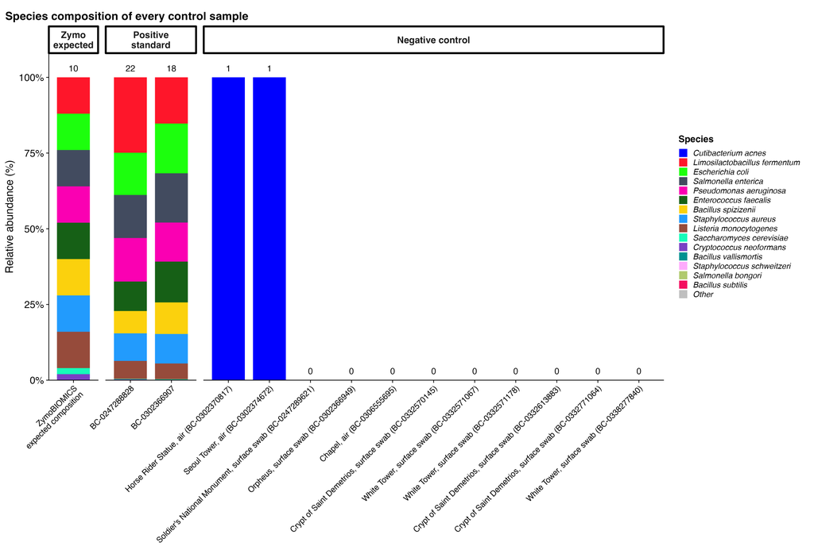

```r
FIGS1_DIR <- file.path(OUTPUT_DIR, "FigureS1")
CONTROL_TYPE_LABELS <- c(
  positive_control = "Positive\nstandard",
  negative_control = "Negative control"
)
ZYMO_REFERENCE_LABEL <- "Zymo\nexpected"

# Theoretical composition of the ZymoBIOMICS Microbial Community Standard (D6300, genomic DNA basis).
# Names follow MetaPhlAn 4 so the colors match the sequenced standards:
# Zymo's Lactobacillus fermentum is Limosilactobacillus fermentum, and its Bacillus subtilis is Bacillus spizizenii.
zymo_reference <- tibble::tribble(
  ~taxon,                          ~abundance,
  "Pseudomonas_aeruginosa",        12,
  "Escherichia_coli",              12,
  "Salmonella_enterica",           12,
  "Limosilactobacillus_fermentum", 12,
  "Enterococcus_faecalis",         12,
  "Staphylococcus_aureus",         12,
  "Listeria_monocytogenes",        12,
  "Bacillus_spizizenii",           12,
  "Saccharomyces_cerevisiae",       2,
  "Cryptococcus_neoformans",        2
) %>%
  mutate(sample_name_clean = "ZYMO_REFERENCE", bar_label = "ZymoBIOMICS\nexpected composition")

# Controls are shown as sequenced, so species and counts come from the raw table.
raw_species_counts <- tibble(
  sample_name_clean = sample_cols,
  n_species = colSums(
    as.matrix(metaphlan_raw_wide %>% filter(rank_prefix == "s__") %>% select(all_of(sample_cols))) > 0,
    na.rm = TRUE
  )
)

control_key <- metadata %>%
  filter(sample_type %in% names(CONTROL_TYPE_LABELS), sample_name_clean %in% sample_cols) %>%
  left_join(raw_species_counts, by = "sample_name_clean") %>%
  mutate(
    n_species = replace_na(n_species, 0L),
    control_type = factor(CONTROL_TYPE_LABELS[sample_type], levels = c(ZYMO_REFERENCE_LABEL, CONTROL_TYPE_LABELS)),
    control_detail = coalesce(str_squish(as.character(control_info)), ""),
    # Positive standards are a reference mix, not a swab, so no location is printed.
    bar_label = case_when(
      sample_type == "positive_control" ~ sample_name_clean,
      control_detail == "" ~ paste0(monument_name, " (", sample_name_clean, ")"),
      TRUE ~ paste0(monument_name, ", ", str_remove(control_detail, "^Negative "), " (", sample_name_clean, ")")
    )
  ) %>%
  arrange(control_type, desc(n_species), sample_name_clean) %>%
  mutate(bar_label = factor(bar_label, levels = unique(bar_label)))

control_species <- metaphlan_raw_wide %>%
  filter(rank_prefix == "s__") %>%
  mutate(taxon = str_remove(str_extract(clade_name, "[^|]+$"), "^s__")) %>%
  select(taxon, all_of(control_key$sample_name_clean)) %>%
  pivot_longer(-taxon, names_to = "sample_name_clean", values_to = "abundance") %>%
  mutate(abundance = as.numeric(abundance)) %>%
  filter(is.finite(abundance), abundance > 0)

control_top_species <- control_species %>%
  group_by(taxon) %>%
  summarise(max_abundance = max(abundance), .groups = "drop") %>%
  arrange(desc(max_abundance)) %>%
  slice_head(n = 15) %>%
  pull(taxon) %>%
  union(zymo_reference$taxon)

set.seed(RANDOM_SEED)
control_species_colors <- c(
  setNames(Polychrome::createPalette(length(control_top_species), seedcolors = pals::glasbey()), control_top_species),
  Other = "grey75"
)

control_bar_data <- control_species %>%
  mutate(taxon = if_else(taxon %in% control_top_species, taxon, "Other")) %>%
  group_by(sample_name_clean, taxon) %>%
  summarise(abundance = sum(abundance), .groups = "drop") %>%
  # Controls with no detected species keep a zero-height bar so their slot is drawn.
  bind_rows(
    control_key %>%
      filter(!sample_name_clean %in% control_species$sample_name_clean) %>%
      transmute(sample_name_clean, taxon = "Other", abundance = 0)
  ) %>%
  inner_join(control_key %>% select(sample_name_clean, control_type, bar_label), by = "sample_name_clean") %>%
  # The expected ZymoBIOMICS composition is drawn as its own reference bar beside the positive standards.
  bind_rows(zymo_reference %>% mutate(control_type = ZYMO_REFERENCE_LABEL)) %>%
  mutate(
    control_type = factor(control_type, levels = c(ZYMO_REFERENCE_LABEL, CONTROL_TYPE_LABELS)),
    bar_label = factor(bar_label, levels = c(unique(zymo_reference$bar_label), levels(control_key$bar_label))),
    taxon = factor(taxon, levels = c(control_top_species, "Other"))
  )

control_count_labels <- control_key %>%
  select(sample_name_clean, control_type, bar_label, n_species) %>%
  bind_rows(
    zymo_reference %>%
      distinct(sample_name_clean, bar_label) %>%
      mutate(control_type = ZYMO_REFERENCE_LABEL, n_species = nrow(zymo_reference))
  ) %>%
  mutate(
    control_type = factor(control_type, levels = levels(control_bar_data$control_type)),
    bar_label = factor(bar_label, levels = levels(control_bar_data$bar_label))
  ) %>%
  left_join(
    control_bar_data %>% group_by(sample_name_clean) %>% summarise(total = sum(abundance), .groups = "drop"),
    by = "sample_name_clean"
  ) %>%
  mutate(total = replace_na(total, 0))

p_s1 <- ggplot() +
  geom_col(
    data = control_bar_data,
    aes(bar_label, abundance, fill = taxon),
    width = 0.8
  ) +
  geom_text(
    data = control_count_labels,
    aes(bar_label, total + 3, label = n_species),
    size = pt_to_mm(by_mode(13, 6))
  ) +
  facet_grid(cols = vars(control_type), scales = "free_x", space = "free_x") +
  scale_fill_manual(values = control_species_colors, drop = FALSE, name = "Species",
    labels = function(x) str_replace_all(x, "_", " ")) +
  scale_y_continuous(labels = function(x) paste0(x, "%"), limits = c(0, 108), expand = expansion(mult = c(0, 0))) +
  labs(
    title = "Species composition of every control sample",
    x = NULL,
    y = "Relative abundance (%)"
  ) +
  guides(fill = guide_legend(ncol = 1)) +
  paper_theme_continuous() +
  theme(
    axis.text.x = element_text(size = by_mode(12, 6), lineheight = 0.9, angle = 45, hjust = 1, vjust = 1),
    strip.text = element_text(face = "bold", size = by_mode(14, 5.5), lineheight = 0.9),
    strip.clip = "off",
    legend.text = element_text(size = by_mode(12, 5.5), face = "italic"),
    legend.key.size = unit(by_mode(0.5, 0.26), "cm"),
    panel.spacing.x = unit(by_mode(0.8, 0.5), "lines"),
    plot.margin = margin(by_mode(8, 4), by_mode(14, 6), by_mode(8, 4), by_mode(8, 4))
  )

figs1_file <- save_panel(p_s1, FIGS1_DIR, "FigureS1_controls", width = 17, height = 11.5)
if (is_print()) figs1_file <- save_page(p_s1, OUTPUT_DIR, "FigureS1_controls", height = 5.2)
knitr::include_graphics(figs1_file)
```

```r
knitr::kable(
  control_key %>%
    select(sample_name_clean, control_type, control_detail, monument_name, country, n_species) %>%
    arrange(control_type, desc(n_species)),
  caption = "Control samples in the metadata, with the number of detected species in the raw table."
)
```

Control samples in the metadata, with the number of detected species in the raw table.

[output not shown]

The combined figure is `paper_output/FigureS1_controls.pdf` and `paper_output/FigureS1_controls.png`. The same panel is also in `paper_output/FigureS1/FigureS1_controls.png`.

## Positive-control noise list and the transformed table

Every species in `BC-0247288828` or `BC-0302366907` that is not one of the ten D6300 organisms is listed below with its ceiling, the higher abundance it reached in those two standards. The transformed table is `input/metaphlan_merged_all_taxa_decontaminated.tsv`; the list is `input/positive_control_noise_species.tsv`. `n_samples_affected` counts every remaining sample, controls included, in which the species was present and therefore reduced.

```r
noise_species <- read_tsv(NOISE_FILE, show_col_types = FALSE)

knitr::kable(
  noise_species %>%
    mutate(species = str_replace_all(species, "_", " "),
           positive_controls = str_replace_all(positive_controls, ";", ", ")),
  digits = 5,
  caption = "Species in the positive standards that are not part of the ZymoBIOMICS D6300 standard, with the ceiling subtracted from every sample."
)
```

Species in the positive standards that are not part of the ZymoBIOMICS D6300 standard, with the ceiling subtracted from every sample.

| species | ceiling_abundance | n_positive_controls | positive_controls | n_samples_affected |
| --- | --- | --- | --- | --- |
| Bacillus vallismortis | 0.01819 | 2 | BC-0247288828, BC-0302366907 | 2 |
| Staphylococcus schweitzeri | 0.00580 | 2 | BC-0247288828, BC-0302366907 | 2 |
| Salmonella bongori | 0.00532 | 2 | BC-0247288828, BC-0302366907 | 2 |
| Bacillus subtilis | 0.00469 | 2 | BC-0247288828, BC-0302366907 | 2 |
| Escherichia albertii | 0.00352 | 2 | BC-0247288828, BC-0302366907 | 2 |
| Escherichia marmotae | 0.00219 | 2 | BC-0247288828, BC-0302366907 | 3 |
| Ralstonia pickettii | 0.00149 | 2 | BC-0247288828, BC-0302366907 | 65 |
| Bacillus paranthracis | 0.00124 | 1 | BC-0247288828 | 1 |
| Bacillus halotolerans | 0.00123 | 2 | BC-0247288828, BC-0302366907 | 2 |
| Bradyrhizobium SGB11337 | 0.00058 | 1 | BC-0247288828 | 36 |
| Escherichia fergusonii | 0.00005 | 1 | BC-0247288828 | 1 |
| Chlorogloea sp CCALA 695 | 0.00001 | 1 | BC-0247288828 | 29 |

```r
decontamination_effect <- tibble(
  sample_name_clean = sample_cols,
  raw_species = colSums(as.matrix(metaphlan_raw_wide %>% filter(rank_prefix == "s__") %>% select(all_of(sample_cols))) > 0),
  transformed_species = colSums(as.matrix(metaphlan_wide %>% filter(rank_prefix == "s__") %>% select(all_of(sample_cols))) > 0)
)
n_retention_changed <- sum((decontamination_effect$raw_species >= MIN_DETECTED_SPECIES) !=
                             (decontamination_effect$transformed_species >= MIN_DETECTED_SPECIES))
decontamination_effect <- decontamination_effect %>%
  filter(raw_species != transformed_species) %>%
  left_join(metadata %>% select(sample_name_clean, sample_type, monument_name), by = "sample_name_clean") %>%
  arrange(sample_type, desc(raw_species - transformed_species))

knitr::kable(
  decontamination_effect,
  caption = paste0(
    "Samples whose detected species count changed after the subtraction. Samples whose retention status (at least ",
    MIN_DETECTED_SPECIES, " species) changed: ", n_retention_changed, "."
  )
)
```

Samples whose detected species count changed after the subtraction. Samples whose retention status (at least 2 species) changed: 0.

| sample_name_clean | raw_species | transformed_species | sample_type | monument_name |
| --- | --- | --- | --- | --- |
| BC-0247288828 | 22 | 10 | positive_control | Soldier’s National Monument |
| BC-0302366907 | 18 | 10 | positive_control | Orpheus |

# Supplementary Figure 2. Sequenced bases, species, and clean bases

Both panels use sequenced bases from the metadata, not the compressed FASTQ file size. Original bases are `original_total_bases`. Clean bases are `host_removed_total_bases`, the bases left after adapter trimming and human-read removal. Both are drawn in gigabases. Positive and negative sequencing controls are not monument samples and are left out of both panels. A sample with no original base count is not drawn. A sample with no host-removed base count stays in panel A and is left out of the paired comparison in panel B.

The analysis notebook drew this scatter from trimmed sequencing depth and added a linear regression line. Panel A keeps dropped samples red and drops the line. The x value is the original R1+R2 sequenced bases. The y value is the species count from the transformed table above: rows that end at `s__`, not genus rows and not `t__` bins. Spearman correlation is `stats::cor.test` (`exact = FALSE` because of ties). A sample is retained at 2 or more of those species.

Panel B gives each monument on the original `monument` list two boxes: original R1+R2 bases, and bases left after adapter trimming and human removal. Clean bases are lower than original bases for every sample. Collapsed site codes and the five focal groups are not used. Monuments with at least 6 paired samples are tested with `rstatix::wilcox_test(paired = TRUE)` on log10 bases, then Benjamini-Hochberg adjustment across those monuments. A `*` marks adjusted p < 0.05. Monuments with fewer than 6 pairs are listed and not tested.

Original bases are dark grey. Clean bases are sky blue (`#56B4E9`). Those fills are library stage, not material.

```r
FIGS2_DIR <- file.path(OUTPUT_DIR, "FigureS2")
depth_species <- size_samples %>%
  mutate(log10_original_bases = log10(original_bases_gb))

spearman_size <- cor.test(
  depth_species$log10_original_bases,
  depth_species$n_species,
  method = "spearman",
  exact = FALSE
)

p_s2a <- ggplot(depth_species, aes(log10_original_bases, n_species, color = microbiome_status)) +
  geom_point(alpha = 0.8, size = gs(3)) +
  scale_color_manual(
    values = c(Dropped = DROPPED_SAMPLE_COLOR, Retained = RETAINED_SAMPLE_COLOR),
    drop = FALSE,
    name = "Sample status"
  ) +
  guides(color = guide_legend(override.aes = list(size = gs(4), alpha = 1))) +
  labs(
    tag = "A",
    title = "Original sequenced bases and detected species",
    subtitle = sprintf(
      "Spearman rho = %.3f, p = %.3g",
      unname(spearman_size$estimate),
      spearman_size$p.value
    ),
    x = "log10 original R1+R2 sequenced bases (Gb)",
    y = "Detected species"
  ) +
  paper_theme_continuous() +
  theme(legend.position = "bottom")

monument_levels <- depth_species %>%
  count(monument_name, name = "n_samples") %>%
  arrange(desc(n_samples), monument_name) %>%
  pull(monument_name)

paired_sizes <- depth_species %>%
  filter(is.finite(original_bases_gb), is.finite(clean_bases_gb), original_bases_gb > 0, clean_bases_gb > 0)

if (any(paired_sizes$clean_bases_gb > paired_sizes$original_bases_gb)) {
  stop("Clean bases exceed original bases for at least one sample.")
}

paired_sizes <- paired_sizes %>%
  mutate(
    log10_original = log10(original_bases_gb),
    log10_clean = log10(clean_bases_gb)
  )

pair_counts <- paired_sizes %>%
  count(monument_name, name = "n_pairs")

size_long <- paired_sizes %>%
  select(sample_name_clean, monument_name, log10_original, log10_clean) %>%
  pivot_longer(
    c(log10_original, log10_clean),
    names_to = "library",
    values_to = "log10_gb"
  ) %>%
  mutate(
    library = recode(
      library,
      log10_original = "Original bases",
      log10_clean = "Clean bases"
    ),
    library = factor(library, levels = names(LIBRARY_COLORS))
  ) %>%
  arrange(monument_name, library, sample_name_clean)

size_tests <- size_long %>%
  group_by(monument_name) %>%
  filter(n_distinct(sample_name_clean) >= 6) %>%
  rstatix::wilcox_test(
    log10_gb ~ library,
    paired = TRUE,
    exact = FALSE,
    p.adjust.method = "none"
  ) %>%
  rstatix::adjust_pvalue(method = "BH") %>%
  rstatix::add_significance("p.adj") %>%
  ungroup() %>%
  left_join(pair_counts, by = "monument_name") %>%
  transmute(
    monument = monument_name,
    n_pairs,
    statistic,
    p,
    p_adj = p.adj,
    significance = p.adj.signif
  )

if (!is_print()) knitr::kable(
  size_tests,
  digits = 3,
  caption = "Paired Wilcoxon signed-rank test of log10 original bases versus log10 clean bases. P-values are Benjamini-Hochberg adjusted across tested monuments."
)
```

Paired Wilcoxon signed-rank test of log10 original bases versus log10 clean bases. P-values are Benjamini-Hochberg adjusted across tested monuments.

| monument | n_pairs | statistic | p | p_adj | significance |
| --- | --- | --- | --- | --- | --- |
| Charging Bull | 38 | 741 | 0.000 | 0.000 | **** |
| Fearless Girl | 12 | 78 | 0.003 | 0.003 | ** |
| Monumento as Bandeiras | 20 | 210 | 0.000 | 0.000 | *** |
| Orpheus | 20 | 210 | 0.000 | 0.000 | *** |
| Seoul Tower | 9 | 45 | 0.009 | 0.009 | ** |
| Soldier’s National Monument | 28 | 406 | 0.000 | 0.000 | **** |
| Tel Megiddo | 47 | 1128 | 0.000 | 0.000 | **** |

```r
not_tested <- pair_counts %>%
  filter(n_pairs < 6) %>%
  arrange(desc(n_pairs), monument_name)
if (nrow(not_tested) > 0 && !is_print()) {
  knitr::kable(
    not_tested,
    caption = "Monuments not tested: fewer than 6 samples with both original bases and clean bases."
  )
}
```

Monuments not tested: fewer than 6 samples with both original bases and clean bases.

| monument_name | n_pairs |
| --- | --- |
| Chapel | 4 |
| Crypt of Saint Demetrios | 4 |
| White Tower | 4 |
| Camel Statue | 3 |
| Chafariz | 3 |
| Horse Rider Statue | 3 |
| Monument with many small bells in front of temple | 3 |
| Soviet Union Tank | 3 |
| Washington Square Park Arch | 3 |
| Equestrian statue of Damdin Sukhbaatar | 2 |
| Teshima Statue | 2 |
| Small Lion statue in front of Equestrian statue of Damdin Sukhbaatar | 1 |
| Wagner Statue | 1 |
| Washington Square Park Fountain | 1 |

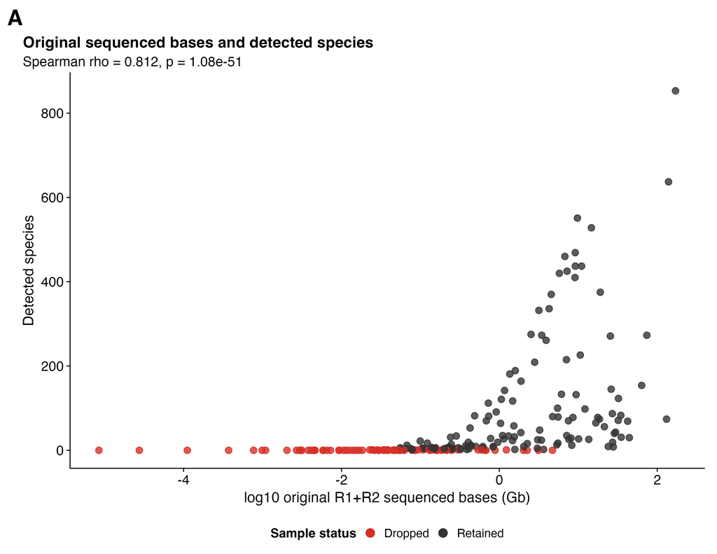

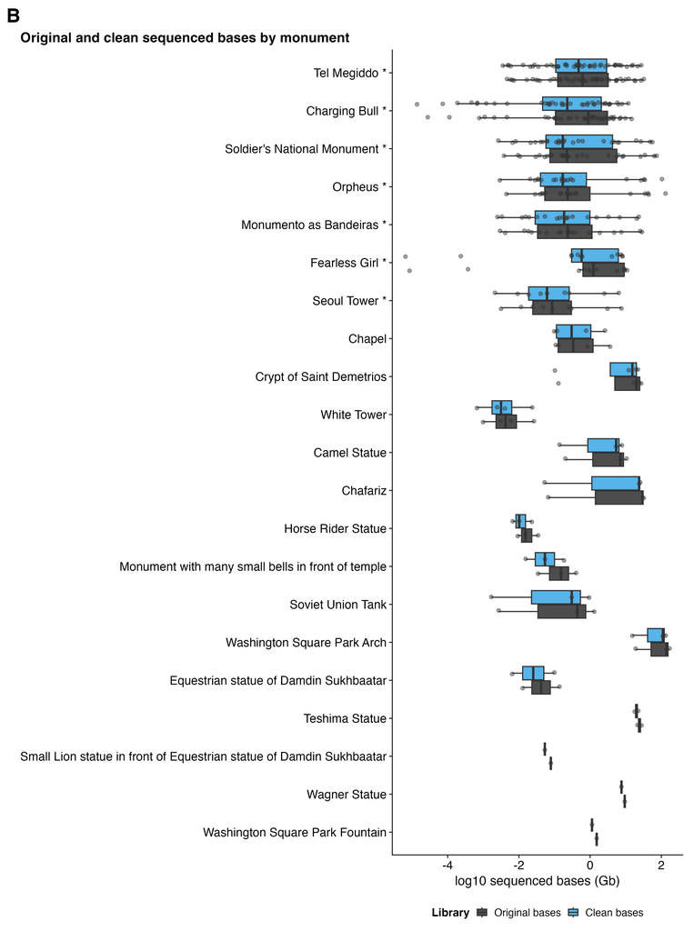

```r
sig_monuments <- size_tests %>%
  filter(is.finite(p_adj), p_adj < 0.05) %>%
  pull(monument)
monument_labels <- setNames(monument_levels, monument_levels)
monument_labels[sig_monuments] <- paste0(monument_labels[sig_monuments], " *")

library_long <- paired_sizes %>%
  select(sample_name_clean, monument_name, original_bases_gb, clean_bases_gb) %>%
  pivot_longer(
    c(original_bases_gb, clean_bases_gb),
    names_to = "library",
    values_to = "bases_gb"
  ) %>%
  mutate(
    library = recode(
      library,
      original_bases_gb = "Original bases",
      clean_bases_gb = "Clean bases"
    ),
    library = factor(library, levels = names(LIBRARY_COLORS)),
    monument_name = factor(monument_name, levels = monument_levels),
    log10_bases_gb = log10(bases_gb)
  )

p_s2b <- ggplot(library_long, aes(monument_name, log10_bases_gb, fill = library)) +
  geom_boxplot(outlier.shape = NA, width = 0.7, position = position_dodge(width = 0.75)) +
  geom_point(
    position = position_jitterdodge(jitter.width = 0.12, dodge.width = 0.75),
    alpha = 0.45,
    size = gs(1.8),
    color = "grey20",
    show.legend = FALSE
  ) +
  scale_x_discrete(limits = rev(monument_levels), labels = monument_labels) +
  scale_fill_manual(values = LIBRARY_COLORS, drop = FALSE, name = "Library") +
  coord_flip() +
  labs(
    tag = "B",
    title = "Original and clean sequenced bases by monument",
    x = NULL,
    y = "log10 sequenced bases (Gb)"
  ) +
  paper_theme_continuous() +
  theme(legend.position = "bottom")

figs2_files <- c(
  save_panel(p_s2a, FIGS2_DIR, "FigureS2A_bases_vs_species", width = 11, height = 8.5),
  save_panel(p_s2b, FIGS2_DIR, "FigureS2B_original_vs_clean_bases", width = 12, height = 3.5 + 0.6 * length(monument_levels))
)
if (is_print()) {
  figs2_print_heights <- c(3.2, 1.0 + 0.2 * length(monument_levels))
  figure_s2 <- (blk(p_s2a) / blk(p_s2b)) + plot_layout(heights = figs2_print_heights)
  figs2_files <- save_page(figure_s2, OUTPUT_DIR, "FigureS2_sequencing_bases", height = sum(figs2_print_heights))
}
knitr::include_graphics(figs2_files)
```

The combined figure is `paper_output/FigureS2_sequencing_bases.pdf` and `paper_output/FigureS2_sequencing_bases.png`. Saved panels are `paper_output/FigureS2/FigureS2A_bases_vs_species.png` and `paper_output/FigureS2/FigureS2B_original_vs_clean_bases.png`.

# Supplementary Figure 3. Species UMAP colored by place, season, material, and climate

This is the same kind of species UMAP as the analysis notebook’s confounding figure, redrawn for the supplement. Samples are those with at least 2 detected species. The embedding is Hellinger-transformed species abundance, then UMAP with the same seed and settings as Figure 2A in the main text. One embedding is colored six ways. An ellipse is drawn only for a group with at least 3 samples.

Material uses the paper colors: rock/stone green, granite pink, metal brown, marble dark yellow, others blue. The other panels use Paul Tol’s color-blind-safe set. Within each of those panels the largest group gets the first, darkest color. Monument names are printed with spaces instead of underscores. The default ggplot rainbow is not used, because several of those hues collapse for red-green color blindness.

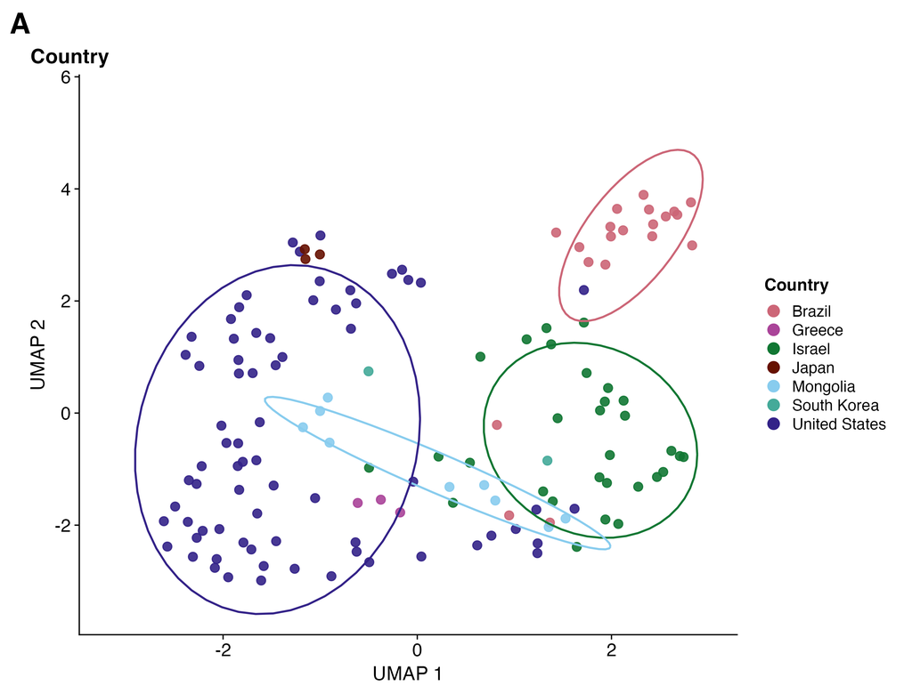

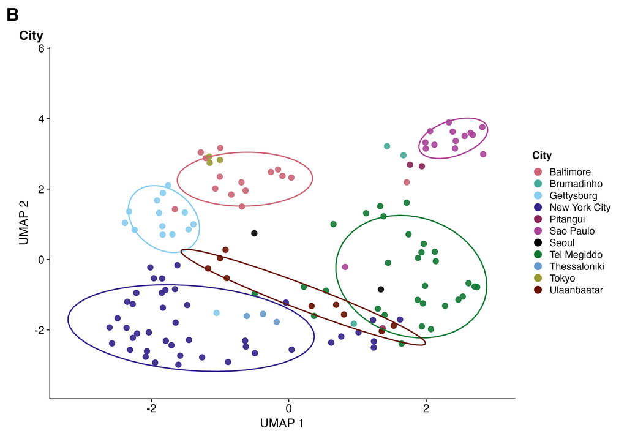

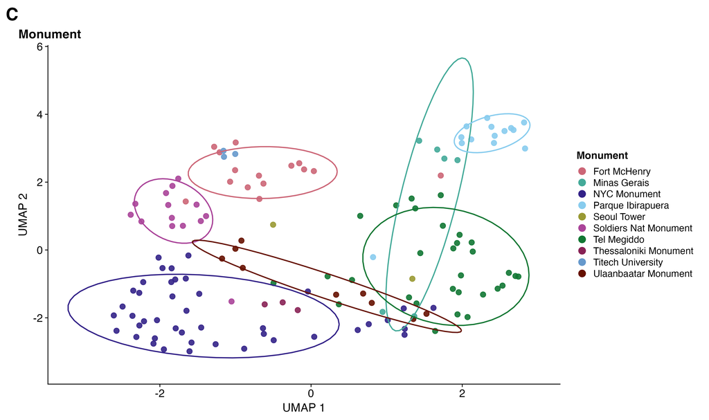

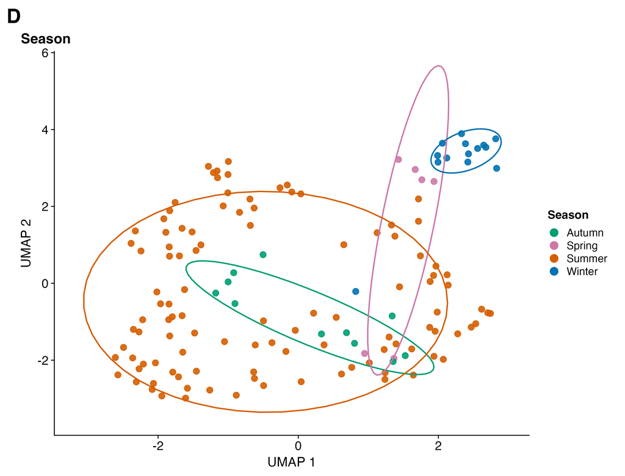

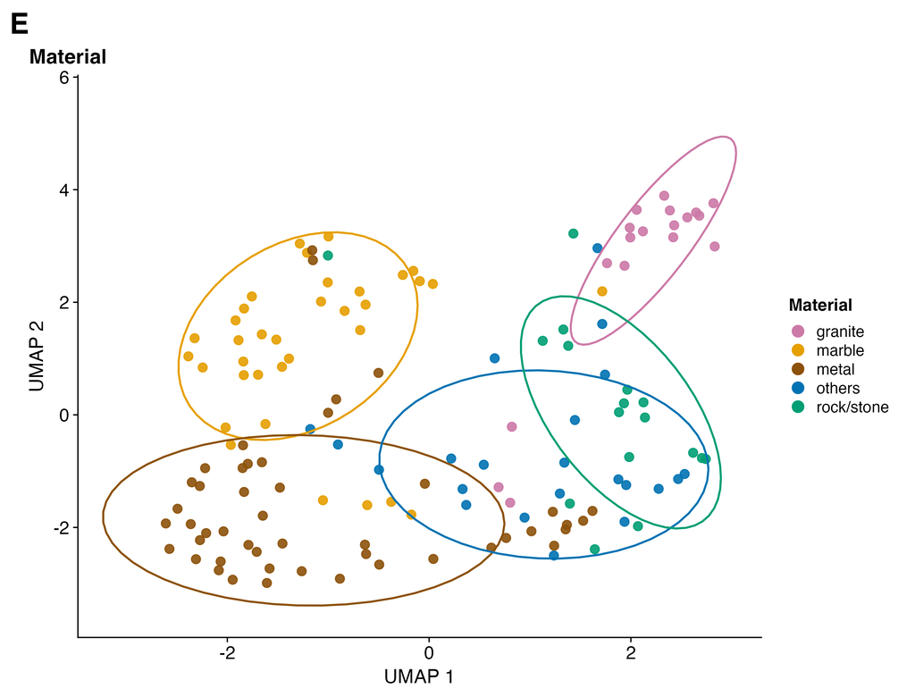

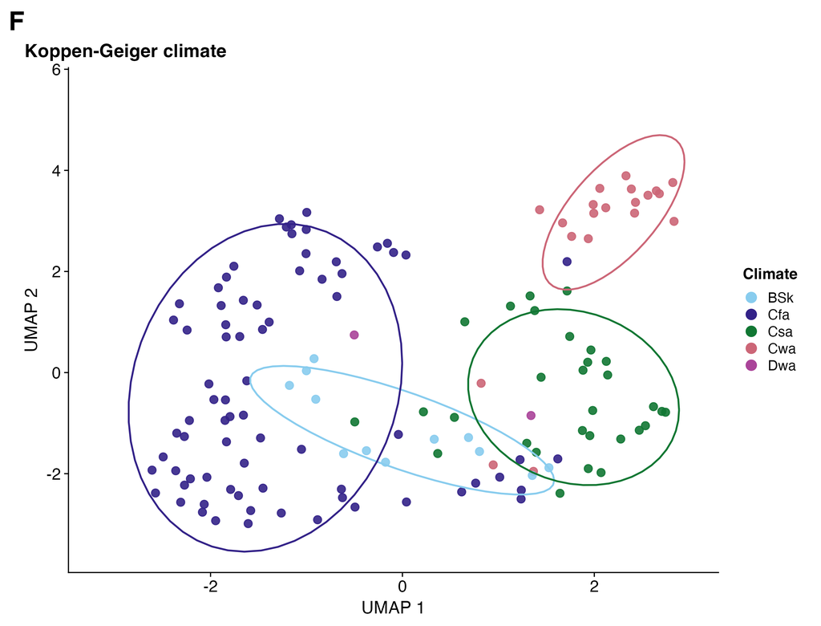

```r
FIGS3_DIR <- file.path(OUTPUT_DIR, "FigureS3")
assign_tol <- function(levels) {
  if (length(levels) > length(TOL_SAFE)) stop("Not enough color-blind-safe colors for this panel.")
  setNames(TOL_SAFE[seq_along(levels)], levels)
}

levels_by_size <- function(x) {
  names(sort(table(x), decreasing = TRUE))
}

retained_ids <- metadata %>%
  filter(!sample_type %in% SEQUENCING_CONTROL_TYPES) %>%
  inner_join(species_counts, by = "sample_name_clean") %>%
  filter(n_species >= MIN_DETECTED_SPECIES, sample_name_clean %in% sample_cols) %>%
  pull(sample_name_clean)

species_table <- metaphlan_wide %>% filter(rank_prefix == "s__")
umap_species_names <- str_remove(str_extract(species_table$clade_name, "[^|]+$"), "^s__")
if (anyDuplicated(umap_species_names)) umap_species_names <- make.unique(umap_species_names)

umap_species_matrix <- t(as.matrix(species_table[, retained_ids, drop = FALSE]))
colnames(umap_species_matrix) <- umap_species_names
umap_species_matrix <- umap_species_matrix[, colSums(umap_species_matrix) > 0, drop = FALSE]
storage.mode(umap_species_matrix) <- "numeric"

hellinger_matrix <- decostand(umap_species_matrix, method = "hellinger")
hellinger_matrix <- hellinger_matrix[, apply(hellinger_matrix, 2, sd, na.rm = TRUE) > 0, drop = FALSE]
set.seed(RANDOM_SEED)
s3_umap <- uwot::umap(
  hellinger_matrix,
  n_neighbors = min(15L, nrow(hellinger_matrix) - 1L),
  min_dist = 0.20,
  n_components = 2L,
  metric = "euclidean",
  scale = FALSE,
  init = "spectral",
  n_threads = 1L,
  verbose = FALSE
)
colnames(s3_umap) <- c("UMAP1", "UMAP2")
rownames(s3_umap) <- rownames(hellinger_matrix)

umap_data <- metadata %>%
  filter(sample_name_clean %in% rownames(umap_species_matrix)) %>%
  mutate(
    monument_name = plot_label(str_replace_all(as.character(monument_final), "_", " ")),
    season_name = plot_label(as.character(seasons_final)),
    material_name = plot_label(normalize_material(materials_final)),
    climate_name = plot_label(as.character(koppen_geiger_code)),
    country = plot_label(as.character(country)),
    city = plot_label(as.character(city))
  )
umap_data <- bind_cols(
  umap_data,
  as.data.frame(s3_umap[umap_data$sample_name_clean, , drop = FALSE])
)

country_colors <- assign_tol(levels_by_size(umap_data$country))
city_colors <- assign_tol(levels_by_size(umap_data$city))
monument_colors <- assign_tol(levels_by_size(umap_data$monument_name))
season_colors <- c(
  Summer = "#D55E00",
  Winter = "#0072B2",
  Autumn = "#009E73",
  Spring = "#CC79A7"
)
climate_colors <- assign_tol(levels_by_size(umap_data$climate_name))

plot_confounder_umap <- function(data, group_col, title, tag, colors, legend_title) {
  dat <- data %>%
    mutate(.group = as.character(.data[[group_col]])) %>%
    filter(!is.na(.group), .group != "", .group != "Unknown")
  ellipse_dat <- dat %>% add_count(.group, name = ".n") %>% filter(.n >= 3)
  p <- ggplot(dat, aes(UMAP1, UMAP2, color = .group)) +
    geom_point(size = gs(3), alpha = 0.9) +
    scale_color_manual(values = colors, name = legend_title, drop = TRUE) +
    guides(color = guide_legend(
      ncol = if (n_distinct(dat$.group) > 12) 2 else 1,
      override.aes = list(size = gs(4), alpha = 1)
    )) +
    labs(tag = tag, title = title, x = "UMAP 1", y = "UMAP 2") +
    paper_theme_continuous() +
    theme(legend.position = "right")
  if (nrow(ellipse_dat) > 0) {
    p <- p + stat_ellipse(
      data = ellipse_dat,
      aes(group = .group),
      level = ELLIPSE_LEVEL,
      linewidth = gs(0.8),
      show.legend = FALSE
    )
  }
  p
}

p_s3a <- plot_confounder_umap(umap_data, "country", "Country", "A", country_colors, "Country")
p_s3b <- plot_confounder_umap(umap_data, "city", "City", "B", city_colors, "City")
p_s3c <- plot_confounder_umap(umap_data, "monument_name", "Monument", "C", monument_colors, "Monument")
p_s3d <- plot_confounder_umap(umap_data, "season_name", "Season", "D", season_colors, "Season")
p_s3e <- plot_confounder_umap(umap_data, "material_name", "Material", "E", MATERIAL_COLORS, "Material")
p_s3f <- plot_confounder_umap(umap_data, "climate_name", "Koppen-Geiger climate", "F", climate_colors, "Climate")

layer_range <- function(p) {
  pieces <- ggplot_build(p)$data
  xs <- unlist(lapply(pieces, function(d) if ("x" %in% names(d)) d$x else numeric()))
  ys <- unlist(lapply(pieces, function(d) if ("y" %in% names(d)) d$y else numeric()))
  c(range(xs, na.rm = TRUE), range(ys, na.rm = TRUE))
}
panel_ranges <- lapply(list(p_s3a, p_s3b, p_s3c, p_s3d, p_s3e, p_s3f), layer_range)
umap_xlim <- range(vapply(panel_ranges, function(r) r[1:2], numeric(2)))
umap_ylim <- range(vapply(panel_ranges, function(r) r[3:4], numeric(2)))
umap_xlim <- umap_xlim + c(-1, 1) * diff(umap_xlim) * 0.04
umap_ylim <- umap_ylim + c(-1, 1) * diff(umap_ylim) * 0.04
share_limits <- function(p) {
  p + coord_cartesian(xlim = umap_xlim, ylim = umap_ylim, expand = FALSE)
}
p_s3a <- share_limits(p_s3a)
p_s3b <- share_limits(p_s3b)
p_s3c <- share_limits(p_s3c)
p_s3d <- share_limits(p_s3d)
p_s3e <- share_limits(p_s3e)
p_s3f <- share_limits(p_s3f)

figs3_files <- c(
  save_panel(p_s3a, FIGS3_DIR, "FigureS3A_umap_country", width = 10.5, height = 8),
  save_panel(p_s3b, FIGS3_DIR, "FigureS3B_umap_city", width = 11.5, height = 8),
  save_panel(p_s3c, FIGS3_DIR, "FigureS3C_umap_monument", width = 13.5, height = 8),
  save_panel(p_s3d, FIGS3_DIR, "FigureS3D_umap_season", width = 10.5, height = 8),
  save_panel(p_s3e, FIGS3_DIR, "FigureS3E_umap_material", width = 10.5, height = 8),
  save_panel(p_s3f, FIGS3_DIR, "FigureS3F_umap_climate", width = 10.5, height = 8)
)
if (is_print()) {
  figure_s3 <- (
    (blk(p_s3a) | blk(p_s3b)) /
    (blk(p_s3c) | blk(p_s3d)) /
    (blk(p_s3e) | blk(p_s3f))
  ) + plot_layout(heights = c(3.3, 3.3, 3.3))
  figs3_files <- save_page(figure_s3, OUTPUT_DIR, "FigureS3_umap_confounders", height = 9.9)
}
knitr::include_graphics(figs3_files)
```

The combined figure is `paper_output/FigureS3_umap_confounders.pdf` and `paper_output/FigureS3_umap_confounders.png`. Saved panels are in `paper_output/FigureS3/`: `FigureS3A_umap_country.png`, `FigureS3B_umap_city.png`, `FigureS3C_umap_monument.png`, `FigureS3D_umap_season.png`, `FigureS3E_umap_material.png`, and `FigureS3F_umap_climate.png`.

# Supplementary Figure 4. Genus and phylum versions of Figure 2

Figure 2 in the main text is the species comparison of the five focal groups. This figure repeats four of those panels at genus and at phylum: accumulated richness, Shannon diversity, Jaccard NMDS, and the median Jaccard heatmap. Genus is the left column. Phylum is the right column.

The samples are the same five focal groups, kept when a sample has at least 2 detected species. Genus and phylum values are the MetaPhlAn rows that end at `g__` and `p__`. They are not renormalized. Accumulation and Jaccard distances use presence. Shannon uses the reported abundances. The group colors are the material colors from the main figures. Axis names are stacked, and legend names use a plain hyphen.

Shannon uses a Kruskal-Wallis test. The NMDS uses Jaccard distances, PERMANOVA with 999 permutations, and the same seed as Figure 2. Taxa detected in only one sample are omitted, as in Figure 2, so that the NMDS does not collapse. The heatmap shows one triangle: the diagonal is the median distance inside a group, and the other filled cells are the median distance between two groups.

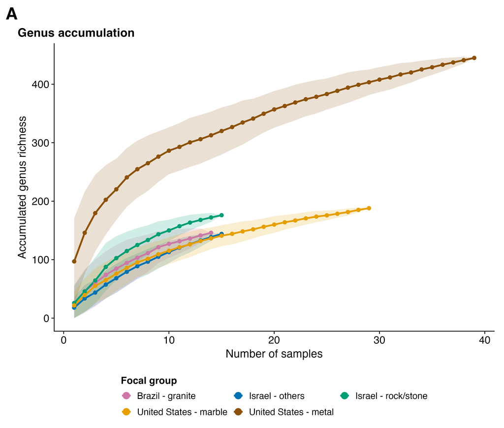

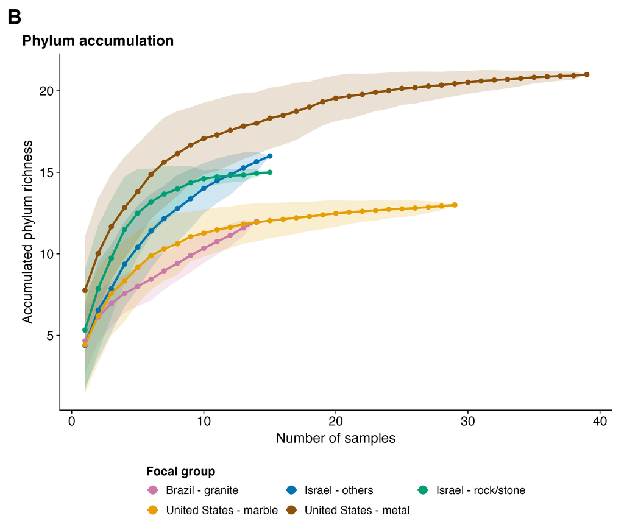

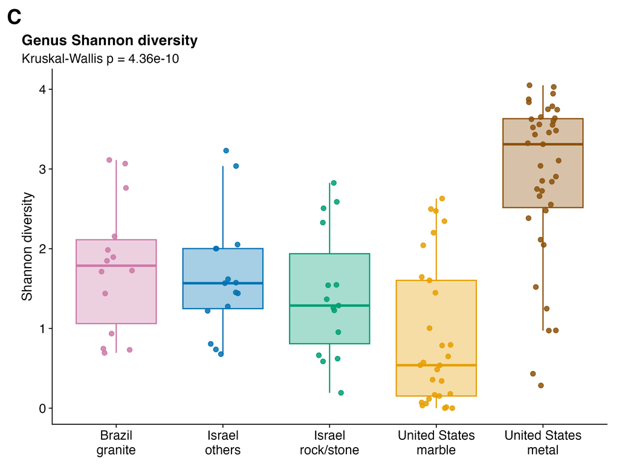

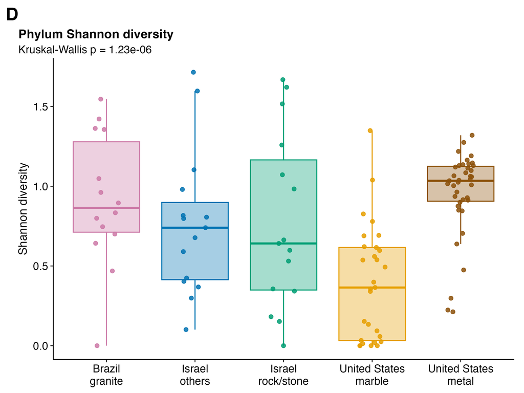

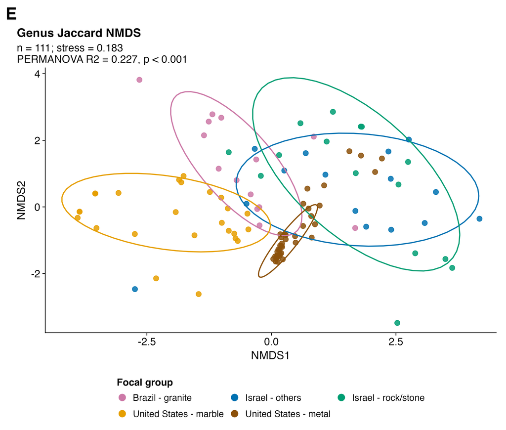

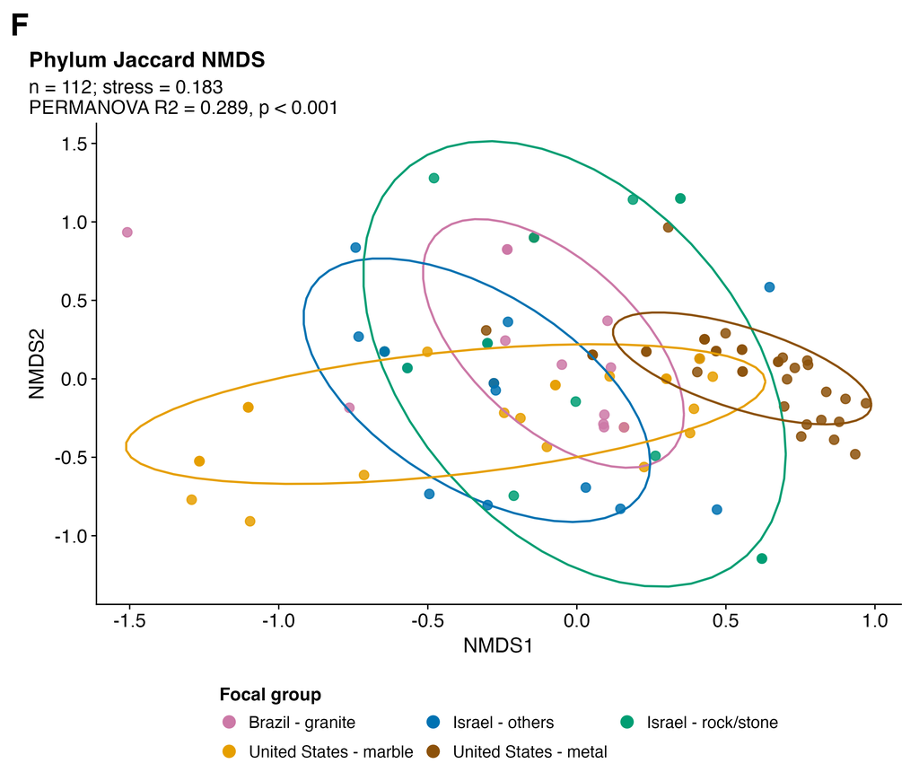

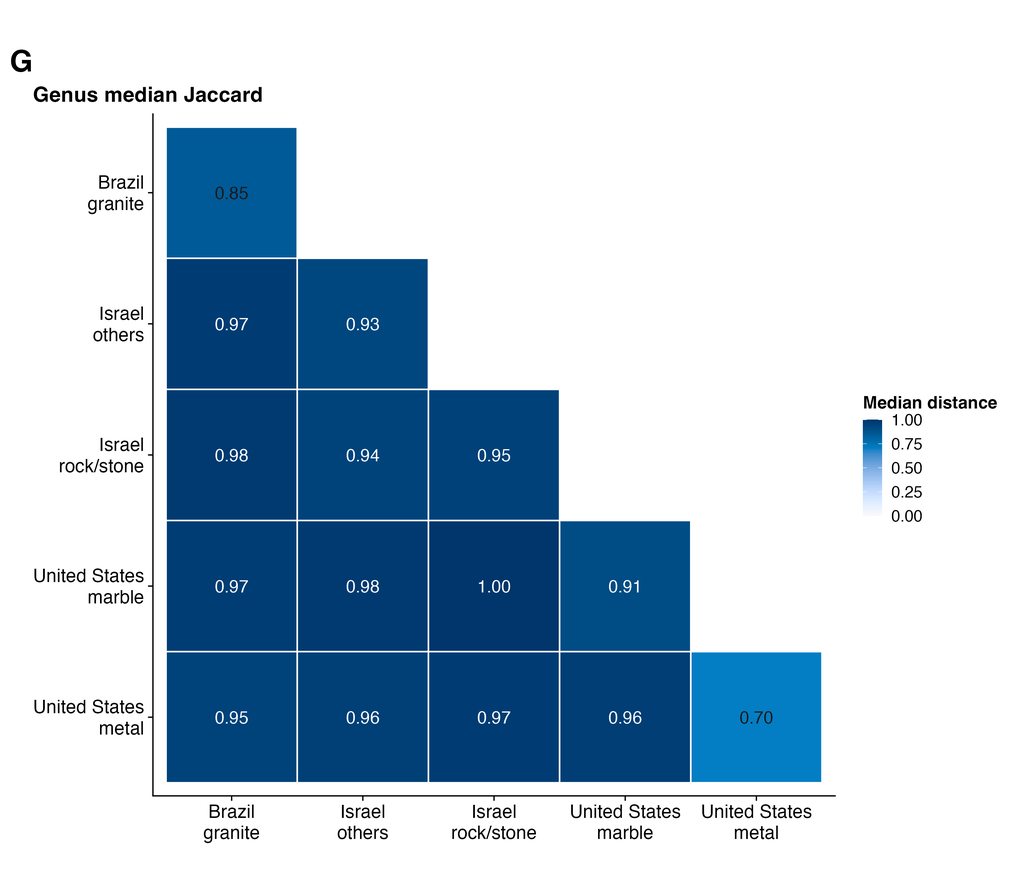

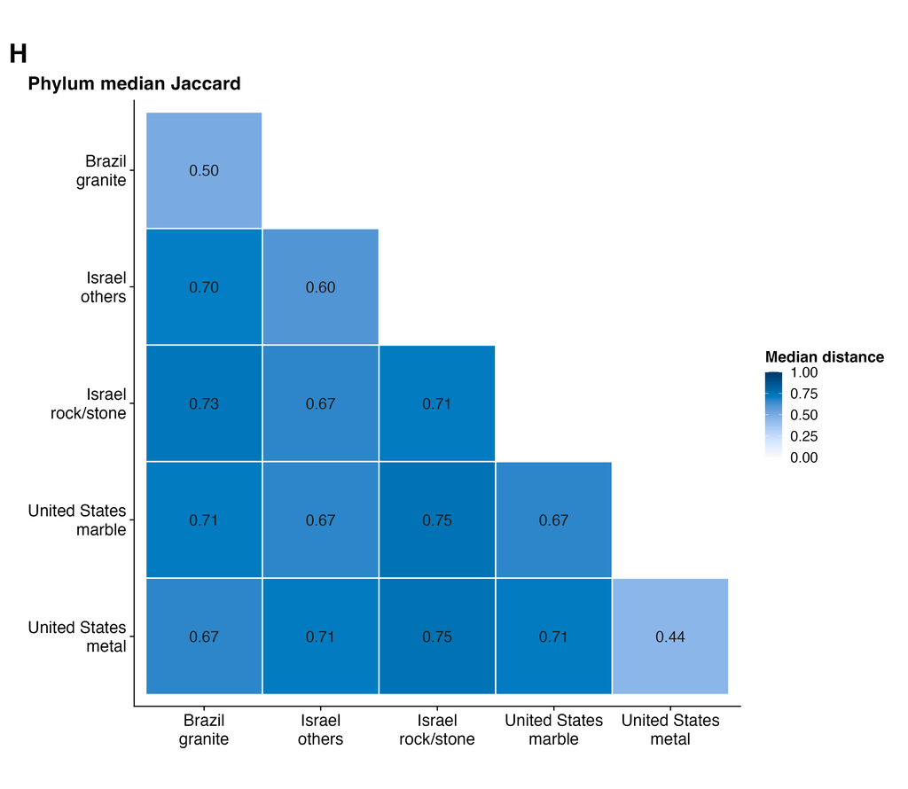

```r
FIGS4_DIR <- file.path(OUTPUT_DIR, "FigureS4")
# Check panels carry their own legend. In the print page one shared legend sits under them.
focal_legend_bottom <- if (is_print()) {
  list(theme(legend.position = "none"))
} else {
  list(
    guides(color = guide_legend(nrow = 2, byrow = TRUE, title.position = "top", override.aes = list(size = 4, alpha = 1))),
    theme(legend.position = "bottom", legend.box.margin = margin(0, 0, 0, 0))
  )
}

# One-row legend of the five focal groups for the print page.
focal_group_legend <- function() {
  src <- ggplot(
    tibble(focal_group = factor(FOCAL_GROUP_LEVELS, levels = FOCAL_GROUP_LEVELS), x = 1, y = 1),
    aes(x, y, color = focal_group)
  ) +
    geom_point(size = 3) +
    scale_color_manual(values = FOCAL_GROUP_COLORS, labels = FOCAL_LEGEND_LABELS, name = "Focal group") +
    guides(color = guide_legend(nrow = 1, override.aes = list(size = 2.4))) +
    theme_void(base_family = FIG_FONT) +
    theme(
      legend.position = "bottom",
      legend.title = element_text(face = "bold", size = FIG_LEGEND_TITLE_SIZE),
      legend.text = element_text(size = FIG_LEGEND_TEXT_SIZE),
      legend.key.size = unit(0.3, "cm")
    )
  patchwork::wrap_elements(full = cowplot::get_legend(src))
}

focal_sample_key <- metadata %>%
  # Positive standards were logged against Orpheus and Soldier's National Monument
  # with material marble; without this filter they would land in United States — marble.
  filter(!sample_type %in% SEQUENCING_CONTROL_TYPES) %>%
  inner_join(species_counts, by = "sample_name_clean") %>%
  mutate(
    n_species = replace_na(n_species, 0L),
    materials_plot = normalize_material(materials_final),
    focal_group = case_when(
      n_species >= MIN_DETECTED_SPECIES &
        country == "Brazil" & monument_final == "Parque_Ibirapuera" & materials_plot == "granite" ~ FOCAL_GROUP_LEVELS[1],
      n_species >= MIN_DETECTED_SPECIES &
        country == "Israel" & monument_final == "Tel_Megiddo" & materials_plot == "others" ~ FOCAL_GROUP_LEVELS[2],
      n_species >= MIN_DETECTED_SPECIES &
        country == "Israel" & monument_final == "Tel_Megiddo" & materials_plot == "rock/stone" ~ FOCAL_GROUP_LEVELS[3],
      n_species >= MIN_DETECTED_SPECIES &
        country == "United States" & monument %in% c("Orpheus", "Soldier's National Monument") & materials_plot == "marble" ~ FOCAL_GROUP_LEVELS[4],
      n_species >= MIN_DETECTED_SPECIES &
        country == "United States" & monument %in% c("Charging Bull", "Fearless Girl") & materials_plot == "metal" ~ FOCAL_GROUP_LEVELS[5],
      TRUE ~ NA_character_
    )
  ) %>%
  filter(!is.na(focal_group), sample_name_clean %in% sample_cols) %>%
  distinct(sample_name_clean, .keep_all = TRUE) %>%
  mutate(focal_group = factor(focal_group, levels = FOCAL_GROUP_LEVELS))
stopifnot(nrow(focal_sample_key) > 0, min(focal_sample_key$n_species) >= MIN_DETECTED_SPECIES)

rank_matrix <- function(prefix, sample_ids) {
  rank_rows <- metaphlan_wide %>% filter(rank_prefix == prefix)
  taxa <- str_remove(str_extract(rank_rows$clade_name, "[^|]+$"), "^[kpcofgst]__")
  if (anyDuplicated(taxa)) taxa <- make.unique(taxa)
  mat <- t(as.matrix(rank_rows[, sample_ids, drop = FALSE]))
  storage.mode(mat) <- "numeric"
  colnames(mat) <- taxa
  mat[, colSums(mat) > 0, drop = FALSE]
}

focal_rank_panels <- function(prefix, rank_label, tags) {
  sample_ids <- focal_sample_key$sample_name_clean
  rank_mat <- rank_matrix(prefix, sample_ids)
  rank_meta <- focal_sample_key %>%
    filter(sample_name_clean %in% rownames(rank_mat)) %>%
    arrange(match(sample_name_clean, rownames(rank_mat)))
  rank_mat <- rank_mat[rank_meta$sample_name_clean, , drop = FALSE]
  presence <- 1L * (rank_mat > 0)

  set.seed(RANDOM_SEED)
  accumulation_data <- bind_rows(lapply(FOCAL_GROUP_LEVELS, function(group_name) {
    ids <- rank_meta %>% filter(focal_group == group_name) %>% pull(sample_name_clean)
    acc <- specaccum(presence[ids, , drop = FALSE], method = "random", permutations = RICHNESS_PERMUTATIONS)
    tibble(
      focal_group = group_name,
      n_samples = acc$sites,
      accumulated_richness = acc$richness,
      richness_sd = acc$sd
    )
  })) %>%
    mutate(focal_group = factor(focal_group, levels = FOCAL_GROUP_LEVELS))

  p_accum <- ggplot(accumulation_data, aes(n_samples, accumulated_richness, color = focal_group, fill = focal_group)) +
    geom_ribbon(
      aes(ymin = pmax(0, accumulated_richness - richness_sd), ymax = accumulated_richness + richness_sd),
      alpha = 0.18,
      color = NA
    ) +
    geom_line(linewidth = gs(1.2)) +
    geom_point(size = gs(2)) +
    scale_color_manual(values = FOCAL_GROUP_COLORS, labels = FOCAL_LEGEND_LABELS, drop = FALSE, name = "Focal group") +
    scale_fill_manual(values = FOCAL_GROUP_COLORS, labels = FOCAL_LEGEND_LABELS, drop = FALSE, name = "Focal group", guide = "none") +
    labs(
      tag = tags[1],
      title = paste(rank_label, "accumulation"),
      x = "Number of samples",
      y = paste("Accumulated", tolower(rank_label), "richness")
    ) +
    paper_theme_continuous() +
    focal_legend_bottom

  alpha_data <- rank_meta %>%
    mutate(shannon = diversity(rank_mat, index = "shannon"))
  shannon_kw <- kruskal.test(shannon ~ focal_group, data = alpha_data)

  p_shannon <- ggplot(alpha_data, aes(focal_group, shannon, color = focal_group, fill = focal_group)) +
    geom_boxplot(outlier.shape = NA, alpha = 0.35) +
    geom_jitter(width = 0.15, size = gs(2.2), alpha = 0.85, show.legend = FALSE) +
    scale_color_manual(values = FOCAL_GROUP_COLORS, drop = FALSE) +
    scale_fill_manual(values = FOCAL_GROUP_COLORS, drop = FALSE) +
    scale_x_discrete(labels = focal_axis_labels()) +
    labs(
      tag = tags[2],
      title = paste(rank_label, "Shannon diversity"),
      subtitle = sprintf("Kruskal-Wallis p = %.3g", shannon_kw$p.value),
      x = NULL,
      y = "Shannon diversity"
    ) +
    paper_theme_upright() +
    theme(legend.position = "none")

  rank_beta <- jaccard_beta(
    rank_mat,
    rank_meta$focal_group,
    nperm = N_PERMUTATIONS,
    seed = RANDOM_SEED
  )
  permanova <- rank_beta$permanova
  nmds_data <- rank_meta %>%
    inner_join(tibble::rownames_to_column(rank_beta$scores, "sample_name_clean"), by = "sample_name_clean")

  p_pcoa <- ggplot(nmds_data, aes(NMDS1, NMDS2, color = focal_group)) +
    geom_point(size = gs(3), alpha = 0.85) +
    stat_ellipse(aes(group = focal_group), level = ELLIPSE_LEVEL, linewidth = gs(0.8), show.legend = FALSE) +
    scale_color_manual(values = FOCAL_GROUP_COLORS, labels = FOCAL_LEGEND_LABELS, drop = FALSE, name = "Focal group") +
    labs(
      tag = tags[3],
      title = paste(rank_label, "Jaccard NMDS"),
      subtitle = sprintf(
        "n = %d; stress = %.3f\nPERMANOVA R2 = %.3f, %s",
        rank_beta$n_samples, rank_beta$stress, permanova$R2[1], perm_p_text(permanova$`Pr(>F)`[1])
      ),
      x = "NMDS1",
      y = "NMDS2"
    ) +
    paper_theme_continuous() +
    focal_legend_bottom
  ellipse_pieces <- ggplot_build(p_pcoa)$data
  ellipse_x <- unlist(lapply(ellipse_pieces, function(d) if ("x" %in% names(d)) d$x else numeric()))
  ellipse_y <- unlist(lapply(ellipse_pieces, function(d) if ("y" %in% names(d)) d$y else numeric()))
  ellipse_xlim <- range(ellipse_x, na.rm = TRUE)
  ellipse_ylim <- range(ellipse_y, na.rm = TRUE)
  ellipse_xlim <- ellipse_xlim + c(-1, 1) * diff(ellipse_xlim) * 0.04
  ellipse_ylim <- ellipse_ylim + c(-1, 1) * diff(ellipse_ylim) * 0.04
  p_pcoa <- p_pcoa + coord_cartesian(xlim = ellipse_xlim, ylim = ellipse_ylim, expand = FALSE)

  bray_matrix <- as.matrix(rank_beta$dist)
  pair_index <- which(upper.tri(bray_matrix), arr.ind = TRUE)
  group_lookup <- setNames(as.integer(rank_meta$focal_group), rank_meta$sample_name_clean)
  group_1 <- group_lookup[rownames(bray_matrix)[pair_index[, 1]]]
  group_2 <- group_lookup[colnames(bray_matrix)[pair_index[, 2]]]
  median_bray <- tibble(
    group_low = pmin(group_1, group_2),
    group_high = pmax(group_1, group_2),
    bray_curtis = bray_matrix[pair_index]
  ) %>%
    group_by(group_low, group_high) %>%
    summarise(median_distance = median(bray_curtis), .groups = "drop") %>%
    mutate(
      x = factor(FOCAL_GROUP_LEVELS[group_low], levels = FOCAL_GROUP_LEVELS),
      y = factor(FOCAL_GROUP_LEVELS[group_high], levels = FOCAL_GROUP_LEVELS),
      label = sprintf("%.2f", median_distance)
    )

  p_median <- ggplot(median_bray, aes(x, y, fill = median_distance)) +
    geom_tile(color = "white", linewidth = gs(0.6)) +
    geom_text(
      aes(label = label, color = ifelse(median_distance > 0.85, "white", "grey10")),
      size = pt_to_mm(by_mode(14, 6)),
      show.legend = FALSE
    ) +
    scale_color_identity() +
    scale_x_discrete(labels = focal_axis_labels(), drop = FALSE) +
    scale_y_discrete(labels = focal_axis_labels(), limits = rev(FOCAL_GROUP_LEVELS), drop = FALSE) +
    colorspace::scale_fill_continuous_sequential(
      palette = "Blues 3",
      rev = TRUE,
      limits = c(0, 1),
      name = "Median distance"
    ) +
    labs(tag = tags[4], title = paste(rank_label, "median Jaccard"), x = NULL, y = NULL) +
    paper_theme_continuous() +
    theme(
      axis.text.y = element_text(lineheight = 0.95),
      panel.grid = element_blank(),
      legend.position = if (is_print()) c(0.80, 0.80) else "right"
    ) +
    coord_fixed()

  list(accum = p_accum, shannon = p_shannon, pcoa = p_pcoa, median = p_median)
}

genus_panels <- focal_rank_panels("g__", "Genus", c("A", "C", "E", "G"))
phylum_panels <- focal_rank_panels("p__", "Phylum", c("B", "D", "F", "H"))

figs4_files <- c(
  save_panel(genus_panels$accum, FIGS4_DIR, "FigureS4A_genus_accumulation", width = 10, height = 8.5),
  save_panel(phylum_panels$accum, FIGS4_DIR, "FigureS4B_phylum_accumulation", width = 10, height = 8.5),
  save_panel(genus_panels$shannon, FIGS4_DIR, "FigureS4C_genus_shannon", width = 10, height = 7.5),
  save_panel(phylum_panels$shannon, FIGS4_DIR, "FigureS4D_phylum_shannon", width = 10, height = 7.5),
  save_panel(genus_panels$pcoa, FIGS4_DIR, "FigureS4E_genus_jaccard_nmds", width = 10, height = 8.5),
  save_panel(phylum_panels$pcoa, FIGS4_DIR, "FigureS4F_phylum_jaccard_nmds", width = 10, height = 8.5),
  save_panel(genus_panels$median, FIGS4_DIR, "FigureS4G_genus_median_jaccard", width = 11.5, height = 10),
  save_panel(phylum_panels$median, FIGS4_DIR, "FigureS4H_phylum_median_jaccard", width = 11.5, height = 10)
)
if (is_print()) {
  figs4_heights <- c(2.2, 2.3, 2.4, 3.1, 0.35)
  figure_s4 <- (
    (blk(genus_panels$accum) | blk(phylum_panels$accum)) /
    (blk(genus_panels$shannon) | blk(phylum_panels$shannon)) /
    (blk(genus_panels$pcoa) | blk(phylum_panels$pcoa)) /
    (blk(genus_panels$median) | blk(phylum_panels$median)) /
    focal_group_legend()
  ) + plot_layout(heights = figs4_heights)
  figs4_files <- save_page(figure_s4, OUTPUT_DIR, "FigureS4_genus_phylum", height = sum(figs4_heights))
}
knitr::include_graphics(figs4_files)
```

The combined figure is `paper_output/FigureS4_genus_phylum.pdf` and `paper_output/FigureS4_genus_phylum.png`. Saved panels are in `paper_output/FigureS4/`: `FigureS4A_genus_accumulation.png`, `FigureS4B_phylum_accumulation.png`, `FigureS4C_genus_shannon.png`, `FigureS4D_phylum_shannon.png`, `FigureS4E_genus_jaccard_nmds.png`, `FigureS4F_phylum_jaccard_nmds.png`, `FigureS4G_genus_median_jaccard.png`, and `FigureS4H_phylum_median_jaccard.png`.

# Supplementary Figure 5. Shared detections and group cores

Figure 3 counts how many taxa fall in each overlap region. It does not say whether a named species is common inside a group. This figure does. Prevalence is the percent of retained samples in a focal group in which the species abundance is above zero. A core species is present in at least 75% of that group’s samples.

The figure is one heatmap. The upper block is every species detected in all five focal groups. The lower block, labeled one-group core, is every species that reaches 75% in one group and is absent from at least one other group. Three species are both shared and core somewhere; they stay in the upper block, with an asterisk in the group where they are core. Fill is prevalence. An asterisk marks a cell at or above 75%. Species names are italic, with underscores printed as spaces. The group labels are the same stacked labels as Figure 3.

The abundance table under the figure is a different number. It is the mean relative abundance, from the transformed table, among the samples in which that species was detected. A blank means the species was absent, so there is no positive mean. No further renormalization is applied beyond the one in `decontaminate_metaphlan.R`.

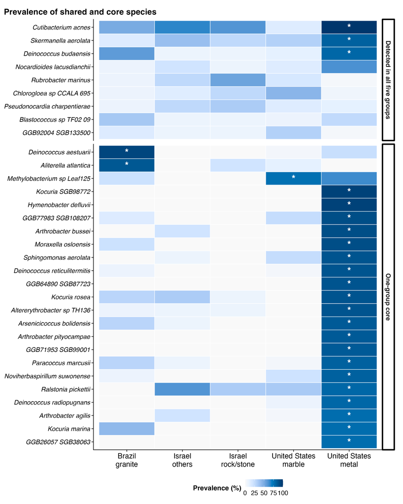

```r
FIGS5_DIR <- file.path(OUTPUT_DIR, "FigureS5")
species_rows <- metaphlan_wide %>% filter(rank_prefix == "s__")
focal_ids <- focal_sample_key$sample_name_clean
species_names <- str_remove(str_extract(species_rows$clade_name, "[^|]+$"), "^s__")
if (anyDuplicated(species_names)) species_names <- make.unique(species_names)
species_matrix <- t(as.matrix(species_rows[, focal_ids, drop = FALSE]))
storage.mode(species_matrix) <- "numeric"
colnames(species_matrix) <- species_names
species_matrix <- species_matrix[, colSums(species_matrix) > 0, drop = FALSE]

species_summary <- bind_rows(lapply(FOCAL_GROUP_LEVELS, function(group_name) {
  ids <- focal_sample_key %>% filter(focal_group == group_name) %>% pull(sample_name_clean)
  group_matrix <- species_matrix[ids, , drop = FALSE]
  present <- group_matrix > 0
  tibble(
    focal_group = group_name,
    taxon = colnames(group_matrix),
    prevalence = 100 * colMeans(present),
    mean_positive_abundance = colMeans(group_matrix * present) / pmax(colMeans(present), .Machine$double.eps)
  ) %>%
    mutate(mean_positive_abundance = if_else(prevalence > 0, mean_positive_abundance, NA_real_))
})) %>%
  mutate(focal_group = factor(focal_group, levels = FOCAL_GROUP_LEVELS))

species_flags <- species_summary %>%
  group_by(taxon) %>%
  summarise(
    n_groups = sum(prevalence > 0),
    n_core = sum(prevalence >= CORE_THRESHOLD * 100),
    mean_prevalence = mean(prevalence),
    .groups = "drop"
  )

shared_species <- species_flags %>%
  filter(n_groups == length(FOCAL_GROUP_LEVELS)) %>%
  arrange(desc(mean_prevalence)) %>%
  pull(taxon)
core_only_species <- species_flags %>%
  filter(n_core >= 1, n_groups < length(FOCAL_GROUP_LEVELS)) %>%
  pull(taxon)

core_group_rank <- species_summary %>%
  filter(taxon %in% core_only_species, prevalence >= CORE_THRESHOLD * 100) %>%
  mutate(group_rank = as.integer(focal_group)) %>%
  arrange(group_rank, desc(prevalence))
core_only_species <- unique(core_group_rank$taxon)

species_block <- c(
  setNames(rep("Detected in all five groups", length(shared_species)), shared_species),
  setNames(rep("One-group core", length(core_only_species)), core_only_species)
)
heatmap_levels <- rev(c(shared_species, core_only_species))

prevalence_data <- species_summary %>%
  filter(taxon %in% names(species_block)) %>%
  mutate(
    taxon = factor(taxon, levels = heatmap_levels),
    block = factor(species_block[as.character(taxon)], levels = unique(species_block)),
    species_label = str_replace_all(as.character(taxon), "_", " ")
  )

p_s5 <- ggplot(prevalence_data, aes(focal_group, taxon, fill = prevalence)) +
  geom_tile(color = "white", linewidth = gs(0.4)) +
  geom_text(
    aes(label = if_else(prevalence >= CORE_THRESHOLD * 100, "*", "")),
    color = "white",
    size = pt_to_mm(by_mode(20, 8)),
    fontface = "bold"
  ) +
  facet_grid(rows = vars(block), scales = "free_y", space = "free_y", labeller = labeller(block = label_wrap_gen(by_mode(40, 12)))) +
  scale_x_discrete(labels = focal_axis_labels(), drop = FALSE) +
  scale_y_discrete(labels = function(x) str_replace_all(x, "_", " ")) +
  colorspace::scale_fill_continuous_sequential(
    palette = "Blues 3",
    rev = TRUE,
    limits = c(0, 100),
    name = "Prevalence (%)"
  ) +
  labs(
    title = "Prevalence of shared and core species",
    x = NULL,
    y = NULL
  ) +
  paper_theme_continuous() +
  theme(
    axis.text.y = element_text(face = "italic", size = by_mode(13, FIG_BASE_SIZE)),
    strip.text.y = element_text(face = "bold", size = by_mode(13, FIG_BASE_SIZE)),
    strip.clip = "off",
    panel.grid = element_blank(),
    legend.position = "bottom",
    plot.margin = margin(by_mode(8, 4), by_mode(18, 8), by_mode(8, 4), by_mode(8, 4))
  )

abundance_table <- prevalence_data %>%
  mutate(
    species = str_replace_all(as.character(taxon), "_", " "),
    group_label = FOCAL_LEGEND_LABELS[as.character(focal_group)],
    block = as.character(block)
  ) %>%
  select(block, species, group_label, mean_positive_abundance) %>%
  mutate(
    mean_positive_abundance = case_when(
      is.na(mean_positive_abundance) ~ NA_character_,
      mean_positive_abundance > 0 & mean_positive_abundance < 0.01 ~ "<0.01",
      TRUE ~ sprintf("%.2f", mean_positive_abundance)
    )
  ) %>%
  pivot_wider(names_from = group_label, values_from = mean_positive_abundance) %>%
  arrange(match(species, str_replace_all(c(shared_species, core_only_species), "_", " "))) %>%
  select(block, species, all_of(unname(FOCAL_LEGEND_LABELS[FOCAL_GROUP_LEVELS])))

write_tsv(abundance_table, file.path(OUTPUT_DIR, "FigureS5_mean_positive_abundance.tsv"))

figs5_file <- save_panel(p_s5, FIGS5_DIR, "FigureS5_shared_core_species", width = 11.5, height = 3.5 + 0.34 * length(heatmap_levels))
if (is_print()) {
  figs5_file <- save_page(p_s5, OUTPUT_DIR, "FigureS5_shared_core_species", height = 1.5 + 0.125 * length(heatmap_levels))
}
knitr::include_graphics(figs5_file)
```

```r
abundance_display <- abundance_table %>%
  mutate(across(-c(block, species), ~ if_else(is.na(.x), "absent", .x)))
knitr::kable(
  abundance_display,
  caption = "Mean MetaPhlAn relative abundance (%) among samples in which the species was detected. Absent means the species was not detected in that group. Values below 0.01% are shown as <0.01."
)
```

Mean MetaPhlAn relative abundance (%) among samples in which the species was detected. Absent means the species was not detected in that group. Values below 0.01% are shown as <0.01.

| block | species | Brazil - granite | Israel - others | Israel - rock/stone | United States - marble | United States - metal |
| --- | --- | --- | --- | --- | --- | --- |
| Detected in all five groups | Cutibacterium acnes | 4.91 | 10.39 | 19.09 | 0.62 | 15.54 |
| Detected in all five groups | Skermanella aerolata | 0.12 | 2.67 | 1.12 | 7.73 | 0.31 |
| Detected in all five groups | Deinococcus budaensis | 4.96 | 0.25 | 1.21 | <0.01 | 0.36 |
| Detected in all five groups | Nocardioides lacusdianchii | 0.64 | 0.31 | 0.07 | 0.26 | 0.84 |
| Detected in all five groups | Rubrobacter marinus | <0.01 | 10.07 | 39.04 | 0.55 | <0.01 |
| Detected in all five groups | Chlorogloea sp CCALA 695 | 0.02 | 2.41 | 0.23 | 31.97 | <0.01 |
| Detected in all five groups | Pseudonocardia charpentierae | 0.03 | 1.26 | 5.44 | <0.01 | 0.03 |
| Detected in all five groups | Blastococcus sp TF02 09 | 0.24 | 0.35 | 0.01 | <0.01 | <0.01 |
| Detected in all five groups | GGB92004 SGB133500 | 0.13 | 7.91 | <0.01 | 0.14 | <0.01 |
| One-group core | Deinococcus aestuarii | 13.57 | absent | absent | 0.01 | <0.01 |
| One-group core | Aliterella atlantica | 16.56 | absent | 0.46 | <0.01 | absent |
| One-group core | Methylobacterium sp Leaf125 | 0.60 | absent | absent | 13.85 | 0.39 |
| One-group core | Kocuria SGB98772 | absent | absent | absent | absent | 10.51 |
| One-group core | Hymenobacter defluvii | absent | absent | absent | absent | 2.04 |
| One-group core | GGB77983 SGB108207 | 0.07 | absent | absent | 5.28 | 5.65 |
| One-group core | Arthrobacter bussei | absent | 2.35 | absent | absent | 2.77 |
| One-group core | Moraxella osloensis | 0.10 | absent | absent | absent | 4.92 |
| One-group core | Sphingomonas aerolata | absent | 4.94 | absent | 11.03 | 3.30 |
| One-group core | Deinococcus reticulitermitis | 0.03 | absent | absent | <0.01 | 0.63 |
| One-group core | GGB64890 SGB87723 | absent | absent | absent | absent | 1.92 |
| One-group core | Kocuria rosea | 0.92 | 13.77 | <0.01 | absent | 5.32 |
| One-group core | Altererythrobacter sp TH136 | 0.04 | 0.89 | 0.14 | absent | 1.19 |
| One-group core | Arsenicicoccus bolidensis | 1.24 | 2.82 | absent | absent | 2.30 |
| One-group core | Arthrobacter pityocampae | absent | absent | absent | absent | 1.88 |
| One-group core | GGB71953 SGB99001 | absent | absent | absent | absent | 2.41 |
| One-group core | Paracoccus marcusii | 2.86 | 8.69 | absent | 0.01 | 1.91 |
| One-group core | Noviherbaspirillum suwonense | 0.54 | absent | absent | 0.29 | 1.01 |
| One-group core | Ralstonia pickettii | absent | 3.74 | 8.67 | 0.52 | 1.20 |
| One-group core | Deinococcus radiopugnans | absent | absent | absent | 0.02 | 1.37 |
| One-group core | Arthrobacter agilis | absent | 2.84 | absent | 1.75 | 1.29 |
| One-group core | Kocuria marina | 1.40 | absent | absent | absent | 1.51 |
| One-group core | GGB26057 SGB38063 | absent | absent | absent | absent | 1.80 |

The heatmap is `paper_output/FigureS5_shared_core_species.pdf` and `paper_output/FigureS5_shared_core_species.png`. The panel is also in `paper_output/FigureS5/`. The table behind it is `paper_output/FigureS5_mean_positive_abundance.tsv`.